# Tesla Stock Analysis

Naswa Nabila Zahrani

2023-09-03

## Library Package

```r
library("forecast")
```

```r
library("graphics")
library("TTR")
library("TSA")
```

## Import Data

```r
library(rio)
datax <- import("https://raw.githubusercontent.com/naswa/MPDW/main/Tugas%201/tesla_stocks%20(1).csv")
Date = datax$Date
Close = datax$Close
Data2 = data.frame(Date,Close)
```

## Eksplorasi Data

```r
View(Data2)
str(Data2)
```

```
## 'data.frame':    1512 obs. of  2 variables:
##  $ Date : IDate, format: "2017-01-03" "2017-01-04" ...
##  $ Close: num  14.5 15.1 15.1 15.3 15.4 ...
```

```r
dim(Data2)
```

```
## [1] 1512    2
```

```r
Data2.ts <- ts(Data2$Close)
```

```r
summary(Data2.ts)
```

```
##    Min. 1st Qu.  Median    Mean 3rd Qu.    Max.
##   11.93   20.58   28.68  113.36  223.65  409.97
```

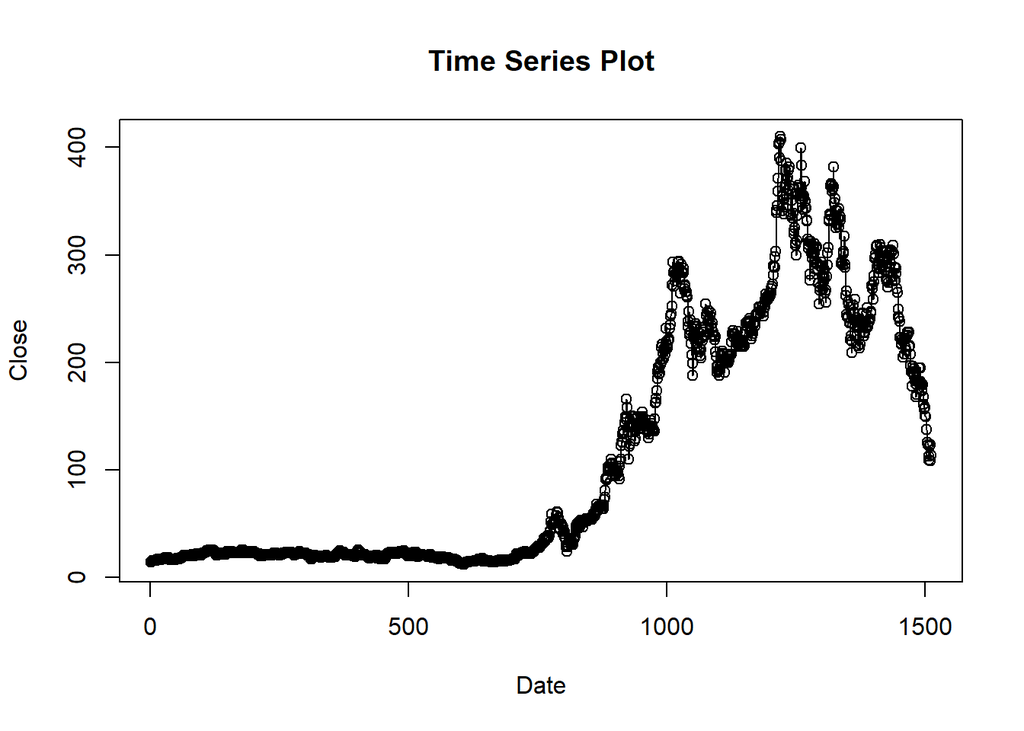

```r
ts.plot(Data2.ts, xlab="Date", ylab="Close",
        main = "Time Series Plot")
points(Data2.ts)
```

```r
#menyimpan plot
#dev.copy(png, "eksplorasi.png")
#dev.off()
```

```r
#membagi data latih dan data uji
training_ma <- Data2[1:1209,]
testing_ma <- Data2[1210:1512,]
train_ma.ts <- ts(training_ma$Close)
test_ma.ts <- ts(testing_ma$Close)
```

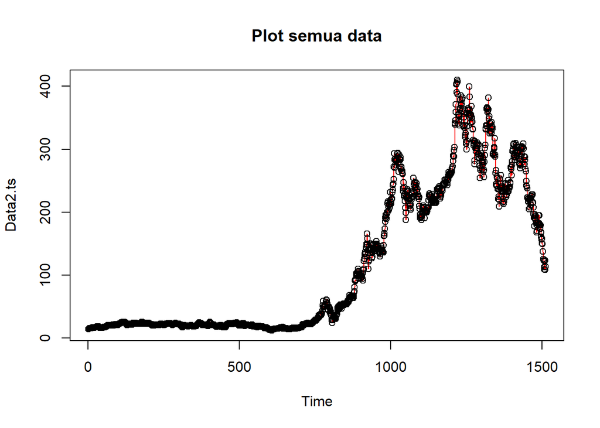

```r
#eksplorasi keseluruhan data
plot(Data2.ts, col="red",main="Plot semua data")
points(Data2.ts)
```

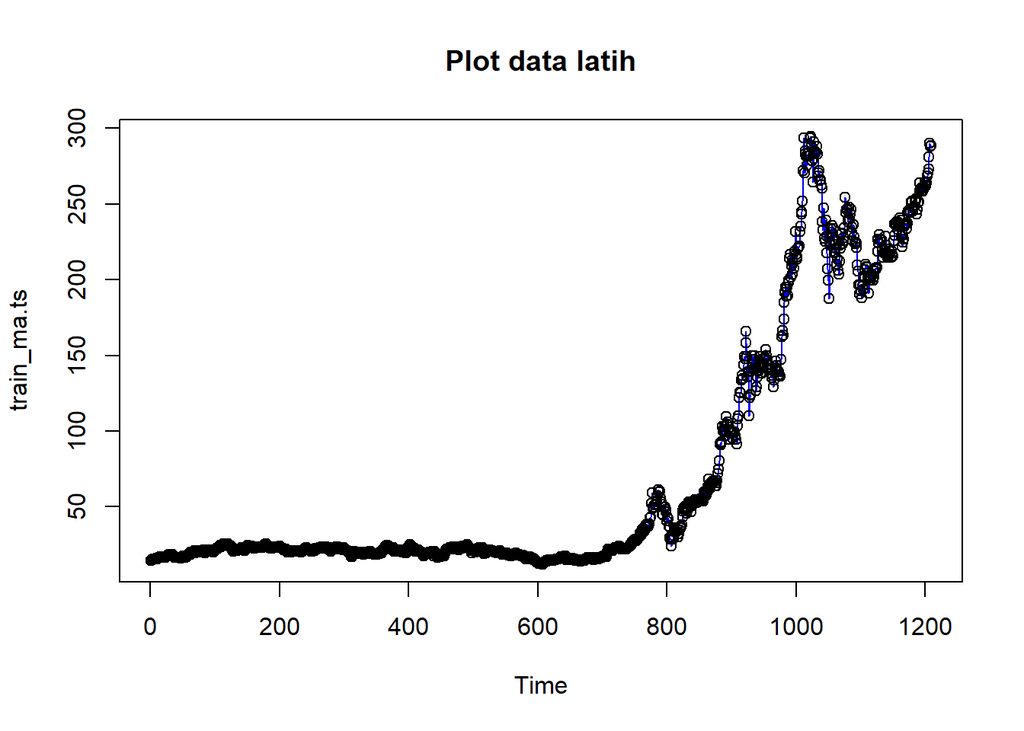

```r
#eksplorasi data latih
plot(train_ma.ts, col="blue",main="Plot data latih")
points(train_ma.ts)
```

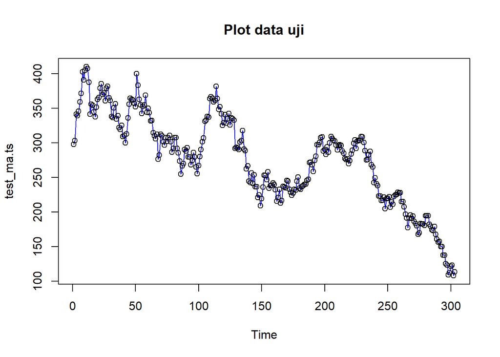

```r
#eksplorasi data uji
plot(test_ma.ts, col="blue",main="Plot data uji")
points(test_ma.ts)
```

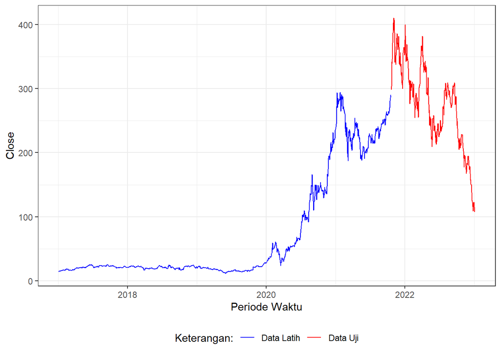

```r
#Eksplorasi dengan GGPLOT
library(ggplot2)
ggplot() +
  geom_line(data = training_ma, aes(x = Date, y = Close, col = "Data Latih")) +
  geom_line(data = testing_ma, aes(x = Date, y = Close, col = "Data Uji")) +
  labs(x = "Periode Waktu", y = "Close", color = "Legend") +
  scale_colour_manual(name="Keterangan:", breaks = c("Data Latih", "Data Uji"),
                      values = c("blue", "red")) +
  theme_bw() + theme(legend.position = "bottom",
                     plot.caption = element_text(hjust=0.5, size=12))
```

## Singla Moving Avarage (SMA)

```r
data.sma<-SMA(train_ma.ts, n=100)
data.sma
```

```
## Time Series:
## Start = 1
## End = 1209
## Frequency = 1
##    [1]        NA        NA        NA        NA        NA        NA        NA
##    [8]        NA        NA        NA        NA        NA        NA        NA
##   [15]        NA        NA        NA        NA        NA        NA        NA
##   [22]        NA        NA        NA        NA        NA        NA        NA
##   [29]        NA        NA        NA        NA        NA        NA        NA
##   [36]        NA        NA        NA        NA        NA        NA        NA
##   [43]        NA        NA        NA        NA        NA        NA        NA
##   [50]        NA        NA        NA        NA        NA        NA        NA
##   [57]        NA        NA        NA        NA        NA        NA        NA
##   [64]        NA        NA        NA        NA        NA        NA        NA
##   [71]        NA        NA        NA        NA        NA        NA        NA
```

[output cut: 162 more lines]

```r
data.ramal<-c(NA,data.sma)
data.ramal #forecast 1 periode ke depan
```

```
##    [1]        NA        NA        NA        NA        NA        NA        NA
##    [8]        NA        NA        NA        NA        NA        NA        NA
##   [15]        NA        NA        NA        NA        NA        NA        NA
##   [22]        NA        NA        NA        NA        NA        NA        NA
##   [29]        NA        NA        NA        NA        NA        NA        NA
##   [36]        NA        NA        NA        NA        NA        NA        NA
##   [43]        NA        NA        NA        NA        NA        NA        NA
##   [50]        NA        NA        NA        NA        NA        NA        NA
##   [57]        NA        NA        NA        NA        NA        NA        NA
##   [64]        NA        NA        NA        NA        NA        NA        NA
##   [71]        NA        NA        NA        NA        NA        NA        NA
##   [78]        NA        NA        NA        NA        NA        NA        NA
##   [85]        NA        NA        NA        NA        NA        NA        NA
##   [92]        NA        NA        NA        NA        NA        NA        NA
##   [99]        NA        NA  18.32481  18.39691  18.46898  18.54515  18.61939
```

[output cut: 158 more lines]

```r
Data.gab<-cbind(aktual=c(train_ma.ts,rep(NA,304)),pemulusan=c(data.sma,rep(NA,304)),ramalan=c(data.ramal,rep(data.ramal[length(data.ramal)],303)))
Data.gab #forecast 24 periode ke depan
```

```
##            aktual pemulusan   ramalan
##    [1,]  14.46600        NA        NA
##    [2,]  15.13267        NA        NA
##    [3,]  15.11667        NA        NA
##    [4,]  15.26733        NA        NA
##    [5,]  15.41867        NA        NA
##    [6,]  15.32467        NA        NA
##    [7,]  15.31533        NA        NA
##    [8,]  15.30600        NA        NA
##    [9,]  15.85000        NA        NA
##   [10,]  15.70533        NA        NA
##   [11,]  15.89067        NA        NA
##   [12,]  16.25067        NA        NA
##   [13,]  16.31533        NA        NA
##   [14,]  16.59467        NA        NA
```

[output cut: 1499 more lines]

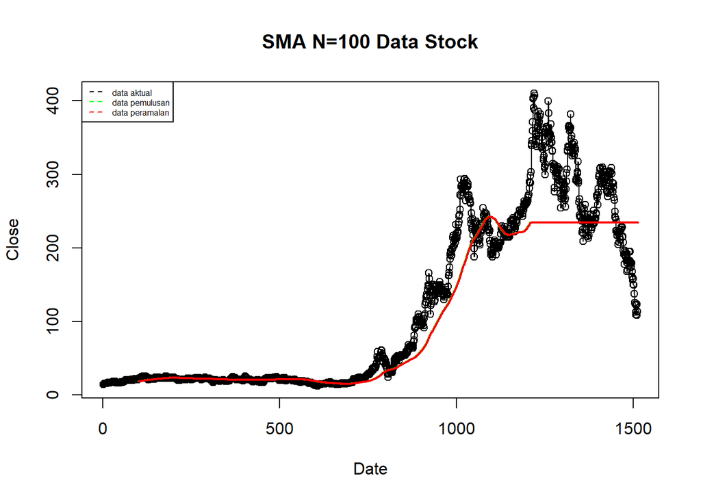

```r
ts.plot(Data2.ts, xlab="Date", ylab="Close", main= "SMA N=100 Data Stock")
points(Data2.ts)
lines(Data.gab[,2],col="green",lwd=2)
lines(Data.gab[,3],col="red",lwd=2)
legend("topleft",c("data aktual","data pemulusan","data peramalan"), lty=8, col=c("black","green","red"), cex=0.5)
```

```r
#Menghitung nilai keakuratan data latih
error_train.sma = train_ma.ts-data.ramal[1:length(train_ma.ts)]
SSE_train.sma = sum(error_train.sma[101:length(train_ma.ts)]^2)
MSE_train.sma = mean(error_train.sma[101:length(train_ma.ts)]^2)
MAPE_train.sma = mean(abs((error_train.sma[101:length(train_ma.ts)]/train_ma.ts[101:length(train_ma.ts)])*100))

akurasi_train.sma <- matrix(c(SSE_train.sma, MSE_train.sma, MAPE_train.sma))
row.names(akurasi_train.sma)<- c("SSE", "MSE", "MAPE")
colnames(akurasi_train.sma) <- c("Akurasi m = 100")
akurasi_train.sma
```

```
##      Akurasi m = 100
## SSE     772914.96642
## MSE        696.94767
## MAPE        15.68103
```

Dalam hal ini nilai MAPE data latih pada metode pemulusan SMA pada rentang 10%-20%, nilai ini dapat dikategorikan sebagai nilai akurasi yang cukup baik. Selanjutnya dilakukan perhitungan nilai MAPE data uji pada metde pemulusan SMA.

```r
#Menghitung nilai keakuratan data uji
error_test.sma = test_ma.ts-Data.gab[1210:1512,3]
SSE_test.sma = sum(error_test.sma^2)
MSE_test.sma = mean(error_test.sma^2)
MAPE_test.sma = mean(abs((error_test.sma/test_ma.ts*100)))

akurasi_test.sma <- matrix(c(SSE_test.sma, MSE_test.sma, MAPE_test.sma))
row.names(akurasi_test.sma)<- c("SSE", "MSE", "MAPE")
colnames(akurasi_test.sma) <- c("Akurasi m = 100")
akurasi_test.sma
```

```
##      Akurasi m = 100
## SSE     1.817030e+06
## MSE     5.996798e+03
## MAPE    2.330909e+01
```

## Double Moving Avarage

```r
dma <- SMA(data.sma, n = 100)
At <- 2*data.sma - dma
Bt <- 2/(100-1)*(data.sma - dma)
data.dma<- At+Bt
data.ramal2<- c(NA, data.dma)

t = 1:304
f = c()

for (i in t) {
  f[i] = At[length(At)] + Bt[length(Bt)]*(i)
}

data.gab2 <- cbind(aktual = c(train_ma.ts,rep(NA,304)), pemulusan1 = c(data.sma,rep(NA,304)),pemulusan2 = c(data.dma, rep(NA,304)),At = c(At, rep(NA,304)), Bt = c(Bt,rep(NA,304)),ramalan = c(data.ramal2, f[-1]))
data.gab2
```

```
##            aktual pemulusan1 pemulusan2        At            Bt   ramalan
##    [1,]  14.46600         NA         NA        NA            NA        NA
##    [2,]  15.13267         NA         NA        NA            NA        NA
##    [3,]  15.11667         NA         NA        NA            NA        NA
##    [4,]  15.26733         NA         NA        NA            NA        NA
##    [5,]  15.41867         NA         NA        NA            NA        NA
##    [6,]  15.32467         NA         NA        NA            NA        NA
##    [7,]  15.31533         NA         NA        NA            NA        NA
##    [8,]  15.30600         NA         NA        NA            NA        NA
##    [9,]  15.85000         NA         NA        NA            NA        NA
##   [10,]  15.70533         NA         NA        NA            NA        NA
##   [11,]  15.89067         NA         NA        NA            NA        NA
##   [12,]  16.25067         NA         NA        NA            NA        NA
##   [13,]  16.31533         NA         NA        NA            NA        NA
##   [14,]  16.59467         NA         NA        NA            NA        NA
```

[output cut: 1499 more lines]

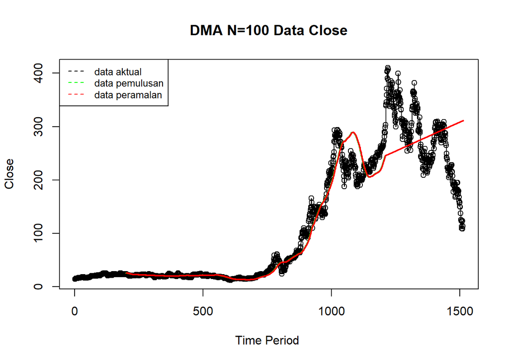

```r
ts.plot(Data2.ts, xlab="Time Period ", ylab="Close", main= "DMA N=100 Data Close")
points(Data2.ts)
lines(data.gab2[,3],col="green",lwd=2)
lines(data.gab2[,6],col="red",lwd=2)
legend("topleft",c("data aktual","data pemulusan","data peramalan"), lty=8, col=c("black","green","red"), cex=0.8)
```

```r
#Menghitung nilai keakuratan data latih
error_train.dma = train_ma.ts-data.ramal2[1:length(train_ma.ts)]
SSE_train.dma = sum(error_train.dma[200:length(train_ma.ts)]^2)
MSE_train.dma = mean(error_train.dma[200:length(train_ma.ts)]^2)
MAPE_train.dma = mean(abs((error_train.dma[200:length(train_ma.ts)]/train_ma.ts[200:length(train_ma.ts)])*100))

akurasi_train.dma <- matrix(c(SSE_train.dma, MSE_train.dma, MAPE_train.dma))
row.names(akurasi_train.dma)<- c("SSE", "MSE", "MAPE")
colnames(akurasi_train.dma) <- c("Akurasi m = 100")
akurasi_train.dma
```

```
##      Akurasi m = 100
## SSE     499793.94574
## MSE        494.84549
## MAPE        13.93074
```

Perhitungan akurasi pada data latih menggunakan nilai MAPE menghasilkan nilai MAPE yang berada pada rentang 10%-20% sehingga dikategorikan cukup baik. Selanjutnya, perhitungan nilai akurasi dilakukan pada data uji.

```r
#Menghitung nilai keakuratan data uji
error_test.dma = test_ma.ts-data.gab2[1210:1512,6]
SSE_test.dma = sum(error_test.dma^2)
MSE_test.dma = mean(error_test.dma^2)
MAPE_test.dma = mean(abs((error_test.dma/test_ma.ts*100)))

akurasi_test.dma <- matrix(c(SSE_test.dma, MSE_test.dma, MAPE_test.dma))
row.names(akurasi_test.dma)<- c("SSE", "MSE", "MAPE")
colnames(akurasi_test.dma) <- c("Akurasi m = 10")
akurasi_test.dma
```

```
##      Akurasi m = 10
## SSE    1.992825e+06
## MSE    6.576981e+03
## MAPE   2.799393e+01
```

Pada data latih, metode DMA lebih baik dibandingkan dengan metode SMA, sedangkan pada data uji, metode SMA lebih baik dibandingkan DMA

## Single Exponential Smoothing & Double Exponential Smoothing

### Pembagian Data

Pembagian data latih dan data uji dilakukan dengan perbandingan 80% data latih dan 20% data uji.

```r
#membagi training dan testing
training<-Data2[1:1209,]
testing<-Data2[1210:1512,]
train.ts <- ts(training$Close)
test.ts <- ts(testing$Close)
```

### Eksplorasi

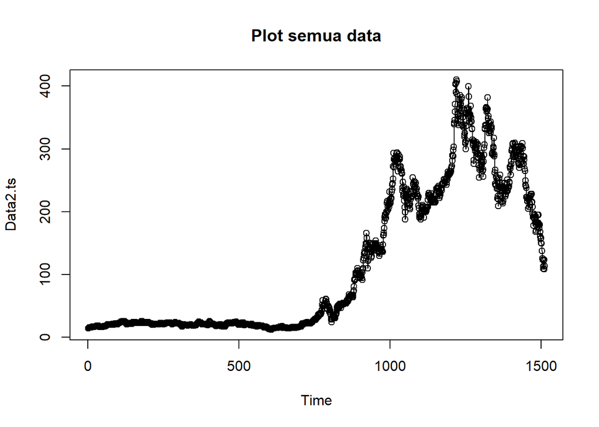

```r
#eksplorasi data
plot(Data2.ts, col="black",main="Plot semua data")
points(Data2.ts)
```

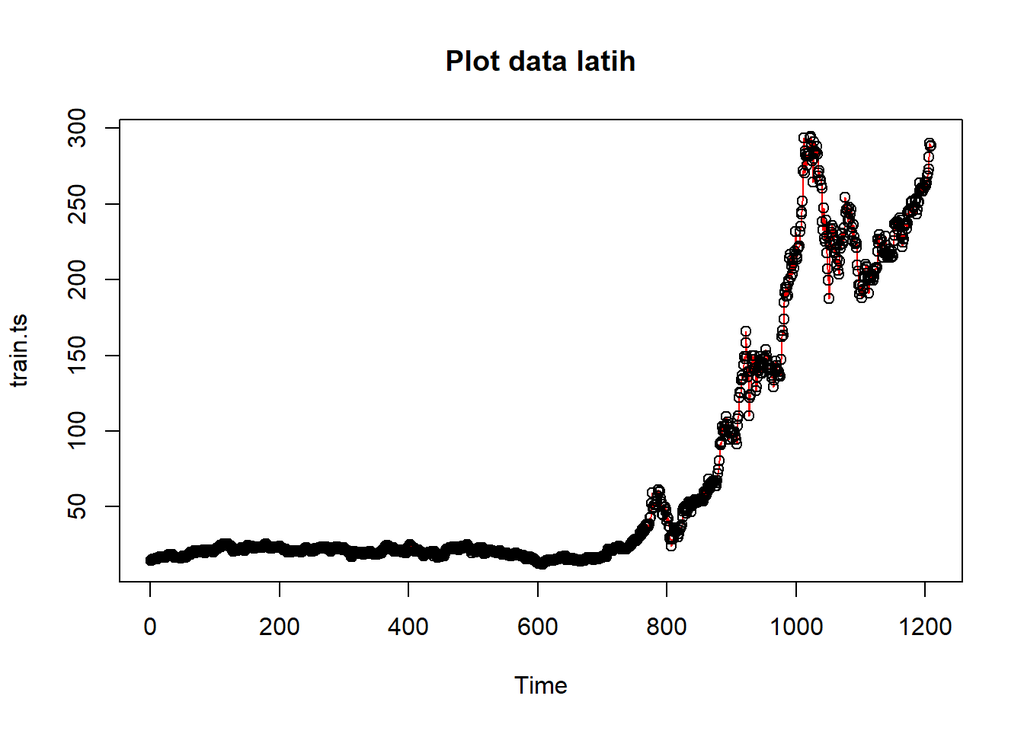

```r
plot(train.ts, col="red",main="Plot data latih")
points(train.ts)
```

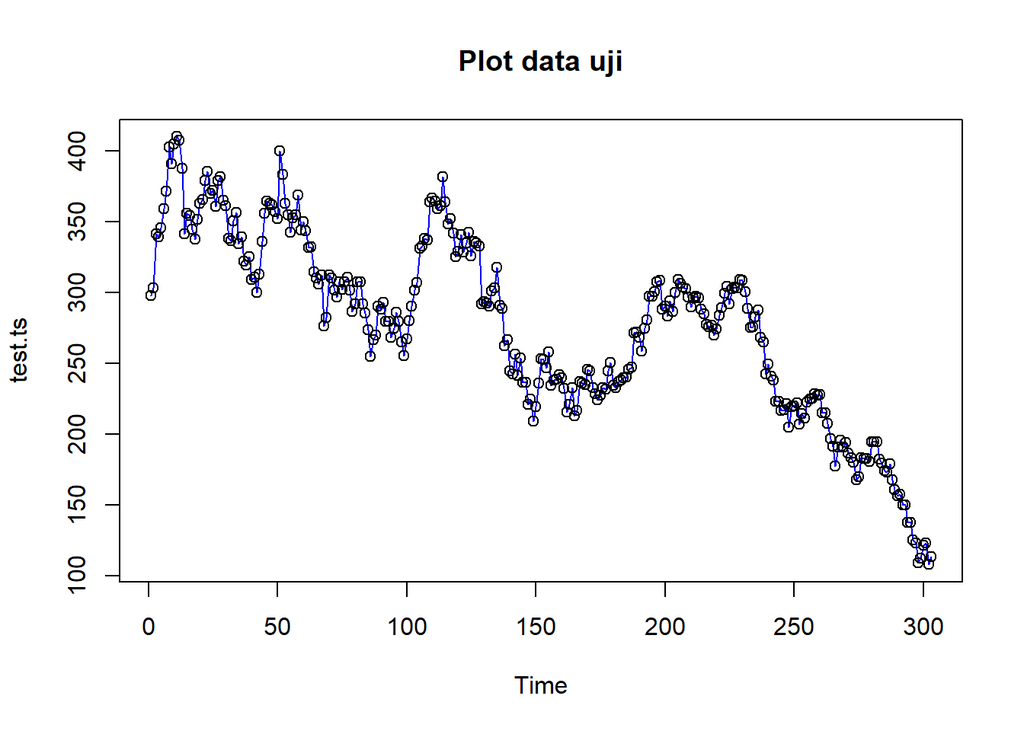

```r
plot(test.ts, col="blue",main="Plot data uji")
points(test.ts)
```

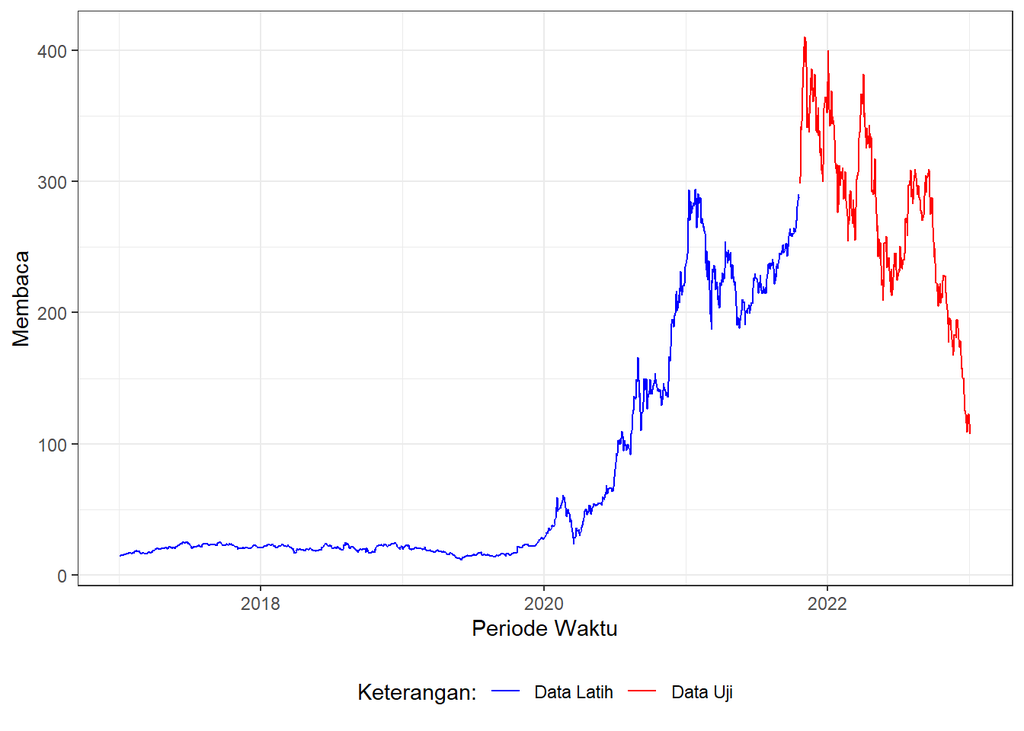

```r
#Eksplorasi dengan GGPLOT
library(ggplot2)
ggplot() +
  geom_line(data = training, aes(x = Date, y = Close, col = "Data Latih")) +
  geom_line(data = testing, aes(x = Date, y = Close, col = "Data Uji")) +
  labs(x = "Periode Waktu", y = "Membaca", color = "Legend") +
  scale_colour_manual(name="Keterangan:", breaks = c("Data Latih", "Data Uji"),
                      values = c("blue", "red")) +
  theme_bw() + theme(legend.position = "bottom",
                     plot.caption = element_text(hjust=0.5, size=12))
```

### SES

Single Exponential Smoothing merupakan metode pemulusan yang tepat digunakan untuk data dengan pola stasioner atau konstan.

Nilai pemulusan pada periode ke-t didapat dari persamaan:

$$\tilde{y}_T=\lambda y_t+(1-\lambda)\tilde{y}_{T-1}$$

Nilai parameter $\lambda$ adalah nilai antara 0 dan 1.

Nilai pemulusan periode ke-t bertindak sebagai nilai ramalan pada periode ke-$(T+\tau)$.

$$\tilde{y}_{T+\tau}(T)=\tilde{y}_T$$

Pemulusan dengan metode SES dapat dilakukan dengan dua fungsi dari *packages* berbeda, yaitu (1) fungsi `ses()` dari *packages* `forecast` dan (2) fungsi `HoltWinters` dari *packages* `stats` .

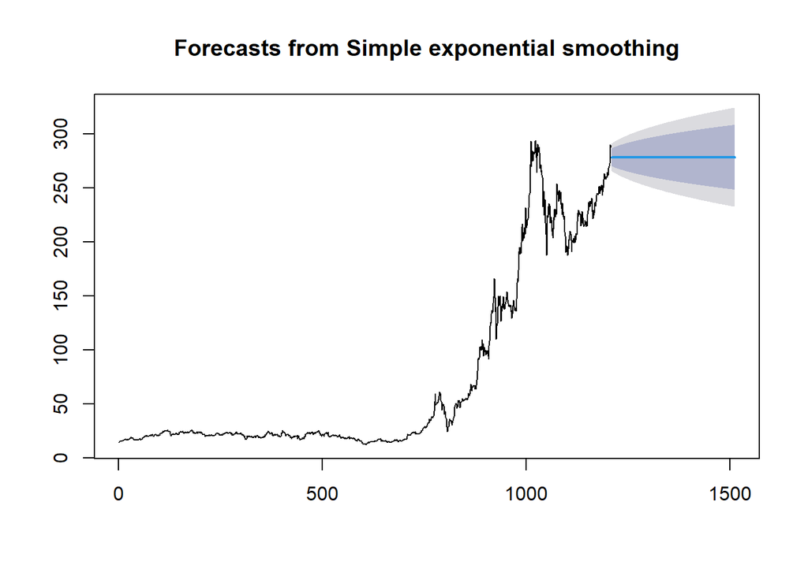

```r
#Cara 1 (fungsi ses)
ses.1 <- ses(train.ts, h = 303, alpha = 0.2)
plot(ses.1)
```

```r
ses.1
```

```
##      Point Forecast    Lo 80    Hi 80    Lo 95    Hi 95
## 1210       278.5854 270.2826 286.8883 265.8873 291.2835
## 1211       278.5854 270.1182 287.0527 265.6359 291.5350
## 1212       278.5854 269.9569 287.2140 265.3892 291.7817
## 1213       278.5854 269.7985 287.3723 265.1470 292.0239
## 1214       278.5854 269.6430 287.5279 264.9092 292.2617
## 1215       278.5854 269.4901 287.6808 264.6754 292.4955
## 1216       278.5854 269.3398 287.8311 264.4454 292.7255
## 1217       278.5854 269.1918 287.9790 264.2192 292.9517
## 1218       278.5854 269.0462 288.1247 263.9964 293.1745
## 1219       278.5854 268.9027 288.2681 263.7770 293.3938
## 1220       278.5854 268.7614 288.4095 263.5608 293.6100
## 1221       278.5854 268.6220 288.5489 263.3477 293.8232
## 1222       278.5854 268.4846 288.6863 263.1375 294.0334
## 1223       278.5854 268.3490 288.8219 262.9302 294.2407
```

[output cut: 289 more lines]

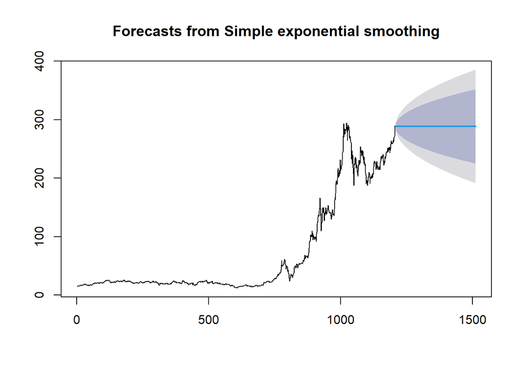

```r
ses.2<- ses(train.ts, h = 303, alpha = 0.7)
plot(ses.2)
```

```r
ses.2
```

```
##      Point Forecast    Lo 80    Hi 80    Lo 95    Hi 95
## 1210       288.3035 283.1103 293.4967 280.3612 296.2458
## 1211       288.3035 281.9644 294.6426 278.6087 297.9983
## 1212       288.3035 280.9960 295.6110 277.1277 299.4793
## 1213       288.3035 280.1417 296.4652 275.8212 300.7858
## 1214       288.3035 279.3688 297.2382 274.6390 301.9680
## 1215       288.3035 278.6575 297.9494 273.5513 303.0557
## 1216       288.3035 277.9953 298.6117 272.5384 304.0685
## 1217       288.3035 277.3731 299.2339 271.5868 305.0201
## 1218       288.3035 276.7844 299.8226 270.6866 305.9204
## 1219       288.3035 276.2244 300.3826 269.8301 306.7768
## 1220       288.3035 275.6892 300.9177 269.0117 307.5953
## 1221       288.3035 275.1759 301.4311 268.2265 308.3804
## 1222       288.3035 274.6819 301.9251 267.4710 309.1360
## 1223       288.3035 274.2051 302.4019 266.7419 309.8651
```

[output cut: 289 more lines]

Untuk mendapatkan gambar hasil pemulusan pada data latih dengan fungsi `ses()` , perlu digunakan fungsi `autoplot()` dan `autolayer()` dari *library packages* `ggplot2` .

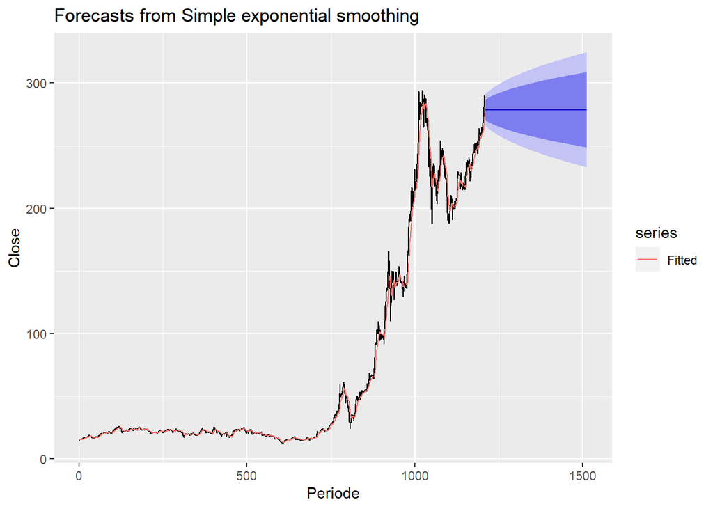

```r
autoplot(ses.1) +
  autolayer(fitted(ses.1), series="Fitted") +
  ylab("Close") + xlab("Periode")
```

Pada fungsi `ses()` , terdapat beberapa argumen yang umum digunakan, yaitu nilia `y` , `gamma` , `beta` , `alpha` , dan `h` .

Nilai `y` adalah nilai data deret waktu, `gamma` adalah parameter pemulusan untuk komponen musiman, `beta` adalah parameter pemulusan untuk tren, dan `alpha` adalah parameter pemulusan untuk stasioner, serta `h` adalah banyaknya periode yang akan diramalkan.

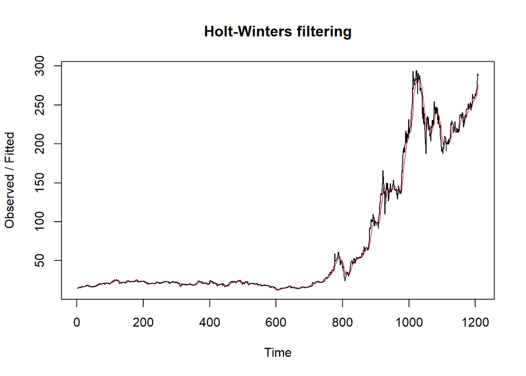

```r
#Cara 2 (fungsi Holtwinter)
ses1<- HoltWinters(train.ts, gamma = FALSE, beta = FALSE, alpha = 0.2)
plot(ses1)
```

```r
#ramalan
ramalan1<- forecast(ses1, h=303)
ramalan1
```

```
##      Point Forecast    Lo 80    Hi 80    Lo 95    Hi 95
## 1210       278.5854 270.4016 286.7693 266.0694 291.1015
## 1211       278.5854 270.2395 286.9313 265.8215 291.3494
## 1212       278.5854 270.0806 287.0903 265.5783 291.5925
## 1213       278.5854 269.9245 287.2464 265.3397 291.8312
## 1214       278.5854 269.7712 287.3997 265.1052 292.0657
## 1215       278.5854 269.6205 287.5504 264.8748 292.2961
## 1216       278.5854 269.4723 287.6986 264.6481 292.5228
## 1217       278.5854 269.3265 287.8444 264.4251 292.7458
## 1218       278.5854 269.1829 287.9879 264.2055 292.9653
## 1219       278.5854 269.0415 288.1293 263.9893 293.1816
## 1220       278.5854 268.9022 288.2687 263.7762 293.3947
## 1221       278.5854 268.7648 288.4060 263.5661 293.6047
## 1222       278.5854 268.6294 288.5415 263.3590 293.8119
## 1223       278.5854 268.4957 288.6751 263.1546 294.0163
```

[output cut: 289 more lines]

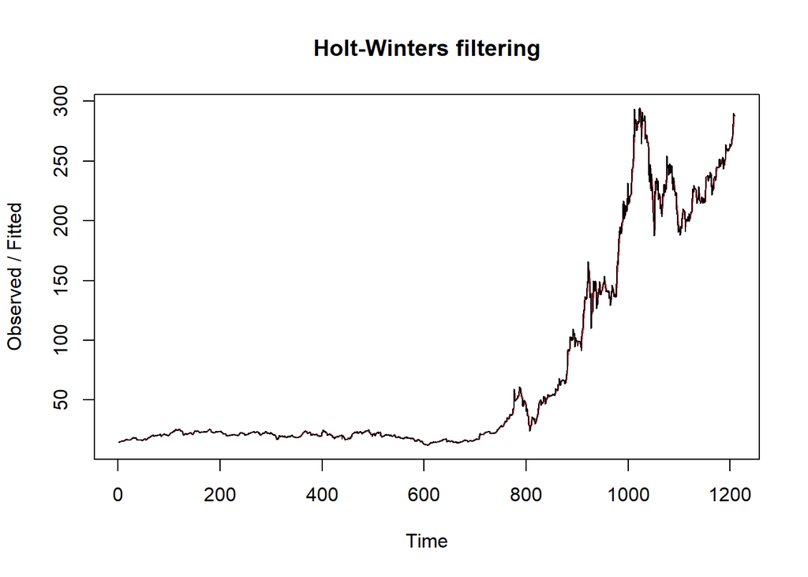

```r
ses2<- HoltWinters(train.ts, gamma = FALSE, beta = FALSE, alpha = 0.7)
plot(ses2)
```

```r
#ramalan
ramalan2<- forecast(ses2, h=303)
ramalan2
```

```
##      Point Forecast    Lo 80    Hi 80    Lo 95    Hi 95
## 1210       288.3035 283.1269 293.4801 280.3866 296.2204
## 1211       288.3035 281.9847 294.6223 278.6397 297.9673
## 1212       288.3035 281.0194 295.5876 277.1634 299.4435
## 1213       288.3035 280.1678 296.4391 275.8611 300.7459
## 1214       288.3035 279.3974 297.2096 274.6827 301.9242
## 1215       288.3035 278.6884 297.9186 273.5985 303.0085
## 1216       288.3035 278.0283 298.5787 272.5889 304.0181
## 1217       288.3035 277.4080 299.1989 271.6403 304.9666
## 1218       288.3035 276.8213 299.7857 270.7430 305.8640
## 1219       288.3035 276.2631 300.3439 269.8892 306.7177
## 1220       288.3035 275.7296 300.8774 269.0734 307.5336
## 1221       288.3035 275.2179 301.3891 268.2908 308.3162
## 1222       288.3035 274.7254 301.8815 267.5377 309.0693
## 1223       288.3035 274.2502 302.3567 266.8109 309.7961
```

[output cut: 289 more lines]

Fungsi `HoltWinters` memiliki argumen yang sama dengan fungsi `ses()` . Argumen-argumen kedua fungsi dapat dilihat lebih lanjut dengan `?ses()` atau `?HoltWinters` .

Nilai parameter $\alpha$ dari kedua fungsi dapat dioptimalkan menyesuaikan dari *error*-nya paling minimumnya. Caranya adalah dengan membuat parameter $\alpha =$ `NULL` .

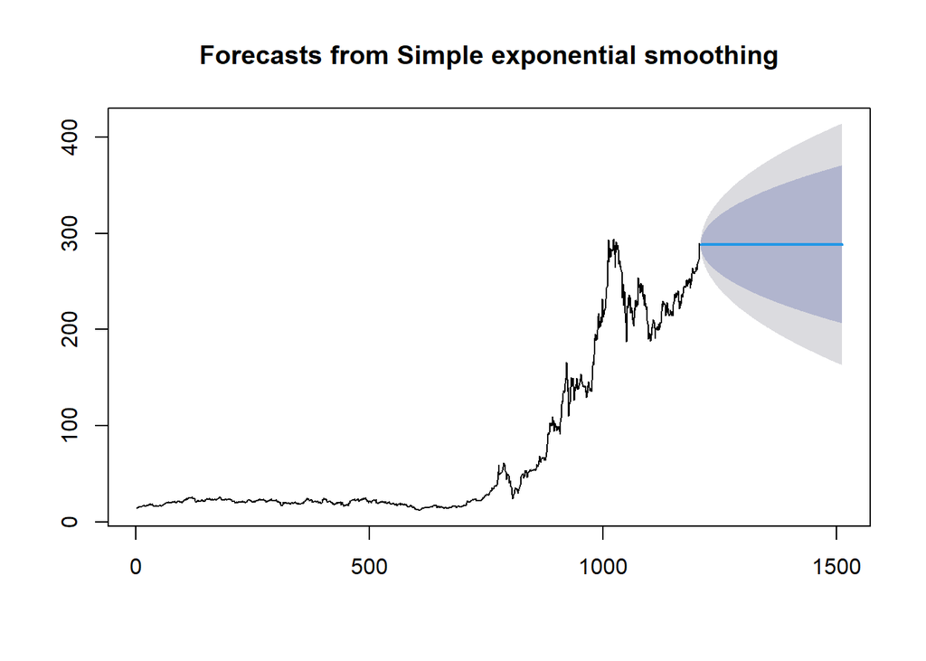

```r
#SES
ses.opt <- ses(train.ts, h = 303, alpha = NULL)
plot(ses.opt)
```

```r
ses.opt
```

```
##      Point Forecast    Lo 80    Hi 80    Lo 95    Hi 95
## 1210       288.5726 283.5352 293.6100 280.8686 296.2767
## 1211       288.5726 281.6746 295.4707 278.0230 299.1223
## 1212       288.5726 280.2186 296.9267 275.7962 301.3491
## 1213       288.5726 278.9811 298.1642 273.9037 303.2416
## 1214       288.5726 277.8860 299.2593 272.2288 304.9165
## 1215       288.5726 276.8931 300.2522 270.7103 306.4350
## 1216       288.5726 275.9782 301.1671 269.3111 307.8342
## 1217       288.5726 275.1254 302.0198 268.0069 309.1383
## 1218       288.5726 274.3236 302.8216 266.7807 310.3646
## 1219       288.5726 273.5646 303.5807 265.6198 311.5255
## 1220       288.5726 272.8421 304.3032 264.5149 312.6304
## 1221       288.5726 272.1514 304.9939 263.4586 313.6867
## 1222       288.5726 271.4886 305.6567 262.4449 314.7004
## 1223       288.5726 270.8506 306.2947 261.4691 315.6762
```

[output cut: 289 more lines]

```r
#Lamda Optimum Holt Winter
sesopt<- HoltWinters(train.ts, gamma = FALSE, beta = FALSE,alpha = NULL)
sesopt
```

```
## Holt-Winters exponential smoothing without trend and without seasonal component.
##
## Call:
## HoltWinters(x = train.ts, alpha = NULL, beta = FALSE, gamma = FALSE)
##
## Smoothing parameters:
##  alpha: 0.935334
##  beta : FALSE
##  gamma: FALSE
##
## Coefficients:
##       [,1]
## a 288.5726
```

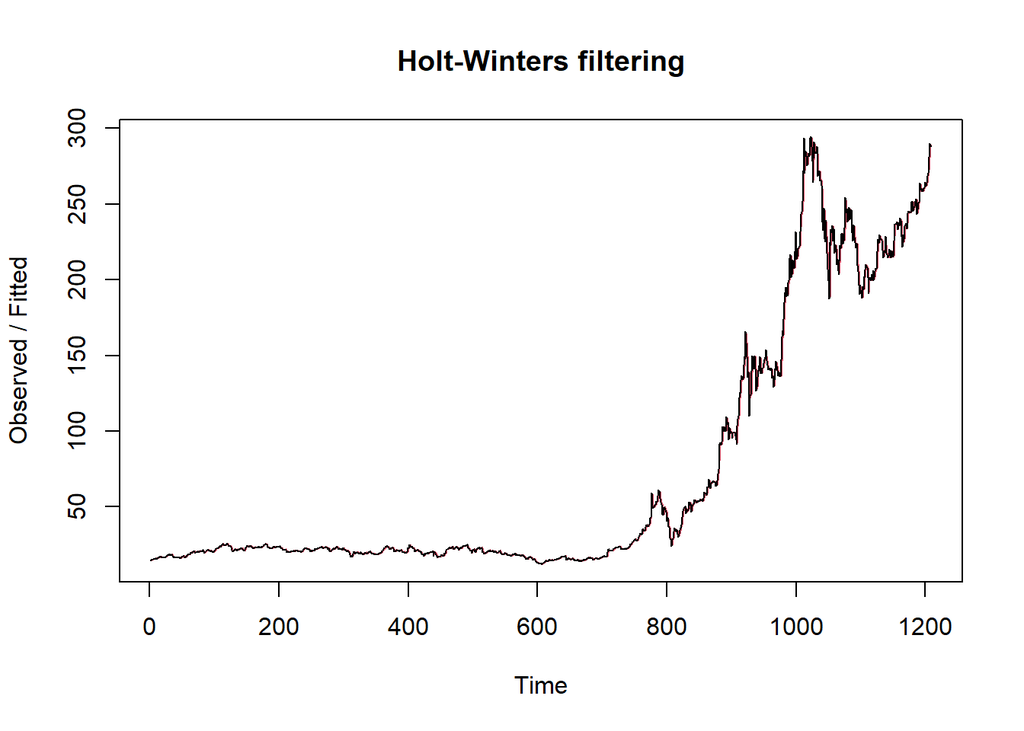

```r
plot(sesopt)
```

```r
#ramalan
ramalanopt<- forecast(sesopt, h=303)
ramalanopt
```

```
##      Point Forecast    Lo 80    Hi 80    Lo 95    Hi 95
## 1210       288.5726 283.5448 293.6004 280.8832 296.2619
## 1211       288.5726 281.6883 295.4569 278.0439 299.1012
## 1212       288.5726 280.2354 296.9098 275.8219 301.3232
## 1213       288.5726 279.0005 298.1446 273.9334 303.2118
## 1214       288.5726 277.9077 299.2374 272.2621 304.8831
## 1215       288.5726 276.9169 300.2282 270.7468 306.3984
## 1216       288.5726 276.0040 301.1412 269.3506 307.7946
## 1217       288.5726 275.1530 301.9921 268.0491 309.0960
## 1218       288.5726 274.3529 302.7923 266.8254 310.3197
## 1219       288.5726 273.5954 303.5497 265.6670 311.4781
## 1220       288.5726 272.8745 304.2707 264.5644 312.5807
## 1221       288.5726 272.1852 304.9599 263.5103 313.6349
## 1222       288.5726 271.5238 305.6213 262.4988 314.6464
## 1223       288.5726 270.8871 306.2580 261.5250 315.6201
```

[output cut: 289 more lines]

Setelah dilakukan peramalan, akan dilakukan perhitungan keakuratan hasil peramalan. Perhitungan akurasi ini dilakukan baik pada data latih dan data uji.

#### Akurasi Data Latih

Perhitungan akurasi data dapat dilakukan dengan cara langsung maupun manual. Secara langsung, nilai akurasi dapat diambil dari objek yang tersimpan pada hasil SES, yaitu *sum of squared errors* (SSE). Nilai akurasi lain dapat dihitung pula dari nilai SSE tersebut.

```r
#Keakuratan Metode
#Pada data training
SSE1<-ses1$SSE
MSE1<-ses1$SSE/length(train.ts)
RMSE1<-sqrt(MSE1)

akurasi1 <- matrix(c(SSE1,MSE1,RMSE1))
row.names(akurasi1)<- c("SSE", "MSE", "RMSE")
colnames(akurasi1) <- c("Akurasi lamda=0.2")
akurasi1
```

```
##      Akurasi lamda=0.2
## SSE       50664.465661
## MSE          41.906092
## RMSE          6.473492
```

```r
SSE2<-ses2$SSE
MSE2<-ses2$SSE/length(train.ts)
RMSE2<-sqrt(MSE2)

akurasi2 <- matrix(c(SSE2,MSE2,RMSE2))
row.names(akurasi2)<- c("SSE", "MSE", "RMSE")
colnames(akurasi2) <- c("Akurasi lamda=0.7")
akurasi2
```

```
##      Akurasi lamda=0.7
## SSE       19820.110877
## MSE          16.393806
## RMSE          4.048926
```

```r
#Cara Manual
fitted1<-ramalan1$fitted
sisaan1<-ramalan1$residuals
head(sisaan1)
```

```
## Time Series:
## Start = 1
## End = 6
## Frequency = 1
## [1]        NA 0.6666670 0.5173336 0.5645329 0.6029603 0.3883682
```

```r
resid1<-training$Close-ramalan1$fitted
head(resid1)
```

```
## Time Series:
## Start = 1
## End = 6
## Frequency = 1
## [1]        NA 0.6666670 0.5173336 0.5645329 0.6029603 0.3883682
```

```r
#Cara Manual
SSE.1=sum(sisaan1[2:length(train.ts)]^2)
SSE.1
```

```
## [1] 50664.47
```

```r
MSE.1 = SSE.1/length(train.ts)
MSE.1
```

```
## [1] 41.90609
```

```r
MAPE.1 = sum(abs(sisaan1[2:length(train.ts)]/train.ts[2:length(train.ts)])*
               100)/length(train.ts)
MAPE.1
```

```
## [1] 4.553049
```

```r
akurasi.1 <- matrix(c(SSE.1,MSE.1,MAPE.1))
row.names(akurasi.1)<- c("SSE", "MSE", "MAPE")
colnames(akurasi.1) <- c("Akurasi lamda=0.2")
akurasi.1
```

```
##      Akurasi lamda=0.2
## SSE       50664.465661
## MSE          41.906092
## MAPE          4.553049
```

```r
fitted2<-ramalan2$fitted
sisaan2<-ramalan2$residuals
head(sisaan2)
```

```
## Time Series:
## Start = 1
## End = 6
## Frequency = 1
## [1]          NA  0.66666700  0.18400010  0.20586603  0.21309381 -0.03007186
```

```r
resid2<-training$Close-ramalan2$fitted
head(resid2)
```

```
## Time Series:
## Start = 1
## End = 6
## Frequency = 1
## [1]          NA  0.66666700  0.18400010  0.20586603  0.21309381 -0.03007186
```

```r
SSE.2=sum(sisaan2[2:length(train.ts)]^2)
SSE.2
```

```
## [1] 19820.11
```

```r
MSE.2 = SSE.2/length(train.ts)
MSE.2
```

```
## [1] 16.39381
```

```r
MAPE.2 = sum(abs(sisaan2[2:length(train.ts)]/train.ts[2:length(train.ts)])*
               100)/length(train.ts)
MAPE.2
```

```
## [1] 2.670982
```

```r
akurasi.2 <- matrix(c(SSE.2,MSE.2,MAPE.2))
row.names(akurasi.2)<- c("SSE", "MSE", "MAPE")
colnames(akurasi.2) <- c("Akurasi lamda=0.7")
akurasi.2
```

```
##      Akurasi lamda=0.7
## SSE       19820.110877
## MSE          16.393806
## MAPE          2.670982
```

Berdasarkan nilai SSE, MSE, RMSE, dan MAPE di antara kedua parameter, nilai parameter $\lambda=0,7$ menghasilkan akurasi yang lebih baik dibanding $\lambda=0,2$ . Hal ini dilihat dari nilai masing-masing ukuran akurasi yang lebih kecil. Berdasarkan nilai MAPE-nya, hasil ini dapat dikategorikan sebagai peramalan sangat baik.

#### Akurasi Data Uji

Akurasi data uji dapat dihitung dengan cara yang hampir sama dengan perhitungan akurasi data latih.

```r
selisih1<-ramalan1$mean-testing$Close
SSEtesting1<-sum(selisih1^2)
MSEtesting1<-SSEtesting1/length(testing)

selisih2<-ramalan2$mean-testing$Close
SSEtesting2<-sum(selisih2^2)
MSEtesting2<-SSEtesting2/length(testing)

selisihopt<-ramalanopt$mean-testing$Close
SSEtestingopt<-sum(selisihopt^2)
MSEtestingopt<-SSEtestingopt/length(testing)

akurasitesting1 <- matrix(c(SSEtesting1,SSEtesting2,SSEtestingopt))
row.names(akurasitesting1)<- c("SSE1", "SSE2", "SSEopt")
akurasitesting1
```

```
##           [,1]
## SSE1   1270462
## SSE2   1308371
## SSEopt 1310235
```

```r
akurasitesting2 <- matrix(c(MSEtesting1,MSEtesting2,MSEtestingopt))
row.names(akurasitesting2)<- c("MSE1", "MSE2", "MSEopt")
akurasitesting2
```

```
##            [,1]
## MSE1   635231.1
## MSE2   654185.7
## MSEopt 655117.7
```

Selain dengan cara di atas, perhitungan nilai akurasi dapat menggunakan fungsi `accuracy()` dari *package* `forecast` . Penggunaannya yaitu dengan menuliskan `accuracy(hasil ramalan, kondisi aktual)` .

```r
#cara lain
accuracy(ramalanopt,testing$Close)
```

```
##                       ME      RMSE      MAE         MPE      MAPE       MASE
## Training set   0.2425972  3.929084  1.90786   0.1887693  2.546068  0.9973479
## Test set     -11.5652408 65.758719 52.37039 -11.6739452 23.274145 27.3770059
##                      ACF1
## Training set -0.003385689
## Test set               NA
```

### DES

Metode pemulusan *Double Exponential Smoothing* (DES) digunakan untuk data yang memiliki pola tren. Metode DES adalah metode semacam SES, hanya saja dilakukan dua kali, yaitu pertama untuk tahapan ‘level’ dan kedua untuk tahapan ‘tren’. Pemulusan menggunakan metode ini akan menghasilkan peramalan tidak konstan untuk periode berikutnya.

Pemulusan dengan metode DES kali ini akan menggunakan fungsi `HoltWinters()` . Jika sebelumnya nilai argumen `beta` dibuat `FALSE` , kali ini argumen tersebut akan diinisialisasi bersamaan dengan nilai `alpha` .

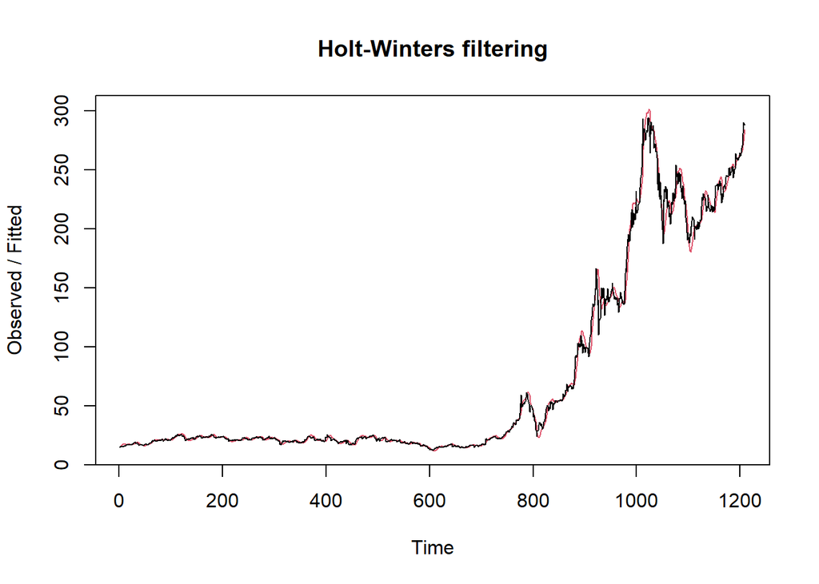

```r
#Lamda=0.2 dan gamma=0.2
des.1<- HoltWinters(train.ts, gamma = FALSE, beta = 0.2, alpha = 0.2)
plot(des.1)
```

```r
#ramalan
ramalandes1<- forecast(des.1, h=303)
ramalandes1
```

```
##      Point Forecast    Lo 80     Hi 80       Lo 95     Hi 95
## 1210       287.7080 279.8866  295.5295  275.746175  299.6699
## 1211       290.5084 282.4649  298.5520  278.206892  302.8100
## 1212       293.3088 284.9725  301.6452  280.559481  306.0582
## 1213       296.1092 287.4053  304.8132  282.797654  309.4208
## 1214       298.9096 289.7615  308.0577  284.918842  312.9004
## 1215       301.7100 292.0418  311.3783  286.923682  316.4964
## 1216       304.5104 294.2479  314.7729  288.815279  320.2056
## 1217       307.3108 296.3832  318.2385  290.598409  324.0232
## 1218       310.1112 298.4512  321.7712  292.278794  327.9436
## 1219       312.9116 300.4561  325.3671  293.862539  331.9607
## 1220       315.7120 302.4017  329.0223  295.355724  336.0683
## 1221       318.5124 304.2920  332.7328  296.764152  340.2607
## 1222       321.3128 306.1303  336.4953  298.093204  344.5324
## 1223       324.1132 307.9200  340.3064  299.347783  348.8786
```

[output cut: 289 more lines]

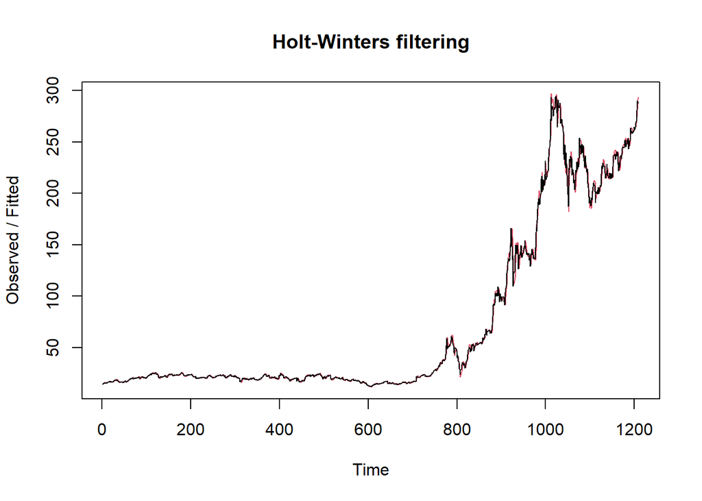

```r
#Lamda=0.6 dan gamma=0.3
des.2<- HoltWinters(train.ts, gamma = FALSE, beta = 0.3, alpha = 0.6)
plot(des.2)
```

```r
#ramalan
ramalandes2<- forecast(des.2, h=303)
ramalandes2
```

```
##      Point Forecast         Lo 80     Hi 80         Lo 95     Hi 95
## 1210       293.8909   288.3837499  299.3981   285.4684385  302.3134
## 1211       297.1749   290.1905447  304.1592   286.4932677  307.8565
## 1212       300.4588   291.6991647  309.2185   287.0620781  313.8556
## 1213       303.7428   292.9656421  314.5199   287.2605632  320.2250
## 1214       307.0268   294.0270715  320.0264   287.1454544  326.9081
## 1215       310.3107   294.9083982  325.7130   286.7549023  333.8665
## 1216       313.5947   295.6271737  331.5622   286.1157497  341.0736
## 1217       316.8786   296.1963651  337.5609   285.2478279  348.5095
## 1218       320.1626   296.6259805  343.6992   284.1664431  356.1588
## 1219       323.4466   296.9240324  349.9691   282.8838493  364.0093
## 1220       326.7305   297.0971296  356.3639   281.4101535  372.0509
## 1221       330.0145   297.1508551  362.8781   279.7538948  380.2751
## 1222       333.2985   297.0900183  369.5069   277.9224279  388.6745
## 1223       336.5824   296.9188271  376.2460   275.9221886  397.2427
```

[output cut: 289 more lines]

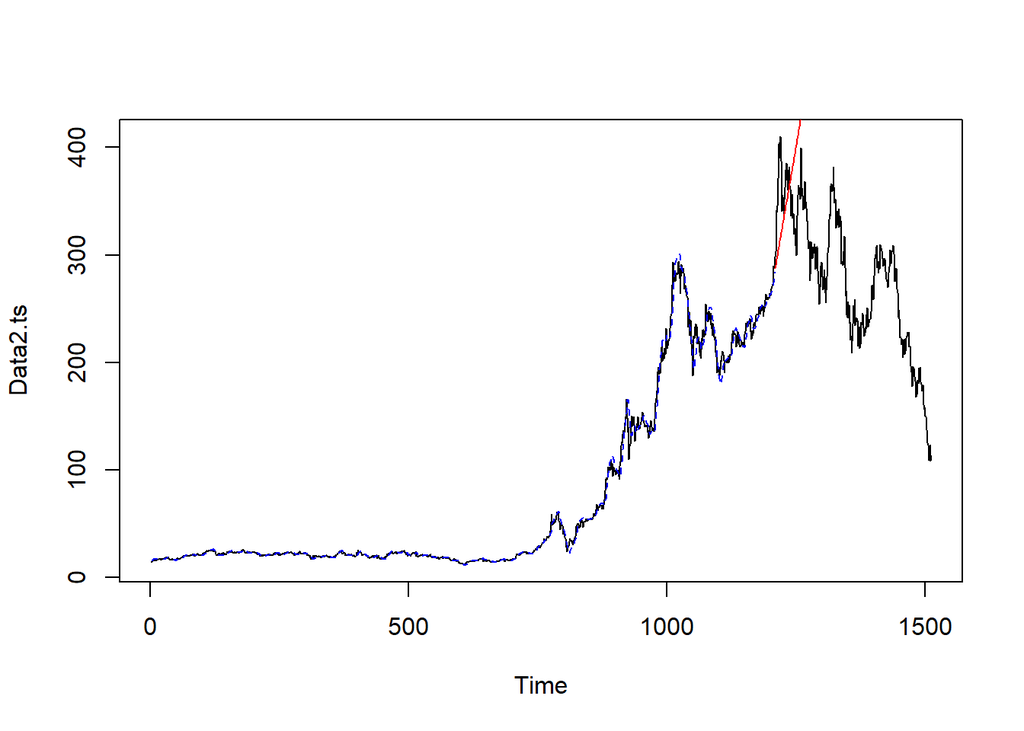

```r
#Visually evaluate the prediction
plot(Data2.ts)
lines(des.1$fitted[,1], lty=2, col="blue")
lines(ramalandes1$mean, col="red")
```

Untuk mendapatkan nilai parameter optimum dari DES, argumen `alpha` dan `beta` dapat dibuat `NULL` seperti berikut.

```r
#Lamda dan gamma optimum
des.opt<- HoltWinters(train.ts, gamma = FALSE)
des.opt
```

```
## Holt-Winters exponential smoothing with trend and without seasonal component.
##
## Call:
## HoltWinters(x = train.ts, gamma = FALSE)
##
## Smoothing parameters:
##  alpha: 0.9280348
##  beta : 0.006079954
##  gamma: FALSE
##
## Coefficients:
##         [,1]
## a 288.613536
## b   0.562528
```

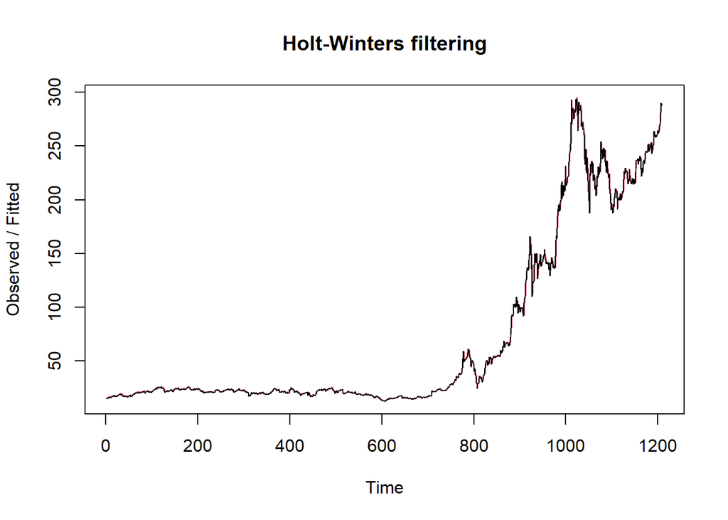

```r
plot(des.opt)
```

```r
#ramalan
ramalandesopt<- forecast(des.opt, h=303)
ramalandesopt
```

```
##      Point Forecast    Lo 80    Hi 80    Lo 95    Hi 95
## 1210       289.1761 284.1394 294.2127 281.4731 296.8790
## 1211       289.7386 282.8478 296.6294 279.2000 300.2771
## 1212       290.3011 281.9425 298.6597 277.5178 303.0845
## 1213       290.8636 281.2450 300.4823 276.1532 305.5741
## 1214       291.4262 280.6818 302.1706 274.9940 307.8583
## 1215       291.9887 280.2142 303.7632 273.9811 309.9963
## 1216       292.5512 279.8190 305.2835 273.0789 312.0235
## 1217       293.1138 279.4808 306.7467 272.2639 313.9636
## 1218       293.6763 279.1889 308.1636 271.5198 315.8328
## 1219       294.2388 278.9356 309.5420 270.8346 317.6431
## 1220       294.8013 278.7149 310.8878 270.1992 319.4035
## 1221       295.3639 278.5222 312.2056 269.6067 321.1210
## 1222       295.9264 278.3538 313.4990 269.0515 322.8013
## 1223       296.4889 278.2069 314.7710 268.5289 324.4489
```

[output cut: 289 more lines]

Selanjutnya akan dilakukan perhitungan akurasi pada data latih maupun data uji dengan ukuran akurasi SSE, MSE dan MAPE.

#### Akurasi Data Latih

```r
#Akurasi Data Training
ssedes.train1<-des.1$SSE
msedes.train1<-ssedes.train1/length(train.ts)
sisaandes1<-ramalandes1$residuals
head(sisaandes1)
```

```
## Time Series:
## Start = 1
## End = 6
## Frequency = 1
## [1]        NA        NA -0.682667 -1.034828 -1.274496 -1.660584
```

```r
mapedes.train1 <- sum(abs(sisaandes1[3:length(train.ts)]/train.ts[3:length(train.ts)])
                      *100)/length(train.ts)

akurasides.1 <- matrix(c(ssedes.train1,msedes.train1,mapedes.train1))
row.names(akurasides.1)<- c("SSE", "MSE", "MAPE")
colnames(akurasides.1) <- c("Akurasi lamda=0.2 dan gamma=0.2")
akurasides.1
```

```
##      Akurasi lamda=0.2 dan gamma=0.2
## SSE                      44923.37553
## MSE                         37.15747
## MAPE                         4.50682
```

```r
ssedes.train2<-des.2$SSE
msedes.train2<-ssedes.train2/length(train.ts)
sisaandes2<-ramalandes2$residuals
head(sisaandes2)
```

```
## Time Series:
## Start = 1
## End = 6
## Frequency = 1
## [1]         NA         NA -0.6826670 -0.6661877 -0.5390142 -0.6364563
```

```r
mapedes.train2 <- sum(abs(sisaandes2[3:length(train.ts)]/train.ts[3:length(train.ts)])
                      *100)/length(train.ts)

akurasides.2 <- matrix(c(ssedes.train2,msedes.train2,mapedes.train2))
row.names(akurasides.2)<- c("SSE", "MSE", "MAPE")
colnames(akurasides.2) <- c("Akurasi lamda=0.6 dan gamma=0.3")
akurasides.2
```

```
##      Akurasi lamda=0.6 dan gamma=0.3
## SSE                     22270.657572
## MSE                        18.420726
## MAPE                        2.920989
```

#### Akurasi Data Uji

```r
#Akurasi Data Testing
selisihdes1<-ramalandes1$mean-testing$Close
selisihdes1
```

```
## Time Series:
## Start = 1210
## End = 1512
## Frequency = 1
##   [1]  -10.291951  -12.718209  -48.311154  -43.367417  -47.043706  -57.303307
##   [7]  -66.822919  -95.552521  -80.555439  -91.708382  -94.257992  -88.850937
##  [13]  -66.333866  -17.053459  -29.069744  -24.789337  -11.958943   -2.481880
##  [19]  -13.461483  -22.087753  -21.744023  -32.503625  -36.306562  -17.559510
##  [25]  -17.082448   -2.922067  -18.478330  -18.267930    1.119136    7.386207
##  [31]   33.396594   38.183654   26.737376   23.801109   48.321506   46.711898
##  [37]   66.385646   71.819374   68.793109   87.950164   88.867229  102.544273
##  [43]   92.481357   71.835066   55.258815   49.079200   53.702929   57.263335
##  [49]   65.347056   72.667441   27.801181   47.331588   70.621974   81.229041
##  [55]   96.609424   89.023162   89.730235   78.590629  106.277682  103.061416
##  [61]  112.228481  126.648872  129.242603  149.499664  156.933391  163.600455
```

[output cut: 40 more lines]

```r
SSEtestingdes1<-sum(selisihdes1^2)
MSEtestingdes1<-SSEtestingdes1/length(testing$Close)
MAPEtestingdes1<-sum(abs(selisihdes1/testing$Close)*100)/length(testing$Close)

selisihdes2<-ramalandes2$mean-testing$Close
selisihdes2
```

```
## Time Series:
## Start = 1210
## End = 1512
## Frequency = 1
##   [1]   -4.1090958   -6.0517870  -41.1611651  -35.7338613  -38.9265834
##   [6]  -48.7026176  -57.7386627  -85.9846979  -70.5040490  -81.1734252
##  [11]  -83.2394683  -77.3488465  -54.3482086   -4.5842348  -16.1169529
##  [16]  -11.3529791    1.9609818   11.9216116    1.4255755   -6.7171277
##  [21]   -5.8898298  -16.1658650  -19.4852351   -0.2546162    0.7060126
##  [26]   15.3499605    0.2772643    0.9712312   20.8418640   27.5925019
##  [31]   54.0864557   59.3570826   48.3943714   45.9416713   70.9456351
##  [36]   69.8195940   89.9769088   95.8942037   93.3515055  112.9921274
##  [41]  114.3927592  128.5533701  118.9740209   98.8112978   82.7186136
##  [46]   77.0225655   82.1298613   86.1738342   94.7411220  102.5450739
##  [51]   58.1623807   78.1763546  101.9503074  113.0409413  128.9048912
```

[output cut: 50 more lines]

```r
SSEtestingdes2<-sum(selisihdes2^2)
MSEtestingdes2<-SSEtestingdes2/length(testing$Close)
MAPEtestingdes2<-sum(abs(selisihdes2/testing$Close)*100)/length(testing$Close)

selisihdesopt<-ramalandesopt$mean-testing$Close
selisihdesopt
```

```
## Time Series:
## Start = 1210
## End = 1512
## Frequency = 1
##   [1]   -8.82393638  -13.48806237  -51.31887535  -48.61300633  -54.52716332
##   [6]  -67.02463230  -78.78211229 -109.74958227  -96.99036826 -110.38117924
##  [11] -115.16865723 -111.99947021  -91.72026719  -44.67772818  -58.93188116
##  [16]  -56.88934215  -46.29681613  -39.05762112  -52.27509210  -63.13923009
##  [21]  -65.03336707  -78.03083705  -84.07164204  -67.56245802  -69.32326401
##  [26]  -57.40075099  -75.19488198  -77.22234996  -60.07315194  -56.04394893
##  [31]  -32.27142991  -29.72223790  -43.40638388  -48.58051887  -26.29798985
##  [36]  -30.14546584  -12.70958582   -9.51372580  -14.77785879    2.14132823
##  [41]    0.82052524   12.25970126   -0.04108273  -22.92524071  -41.73935970
##  [46]  -50.15684268  -47.77098166  -46.44844365  -40.60259063  -35.52007362
##  [51]  -82.62420160  -65.33166259  -44.27914457  -35.90994555  -22.76743054
```

[output cut: 50 more lines]

```r
SSEtestingdesopt<-sum(selisihdesopt^2)
MSEtestingdesopt<-SSEtestingdesopt/length(testing$Close)
MAPEtestingdesopt<-sum(abs(selisihdesopt/testing$Close)*100)/length(testing$Close)

akurasitestingdes <-
  matrix(c(SSEtestingdes1,MSEtestingdes1,MAPEtestingdes1,SSEtestingdes2,MSEtestingdes2,
           MAPEtestingdes2,SSEtestingdesopt,MSEtestingdesopt,MAPEtestingdesopt),
         nrow=3,ncol=3)
row.names(akurasitestingdes)<- c("SSE", "MSE", "MAPE")
colnames(akurasitestingdes) <- c("des ske1","des ske2","des opt")
akurasitestingdes
```

```
##          des ske1     des ske2      des opt
## SSE  8.430914e+07 1.152043e+08 6.448321e+06
## MSE  2.782480e+05 3.802121e+05 2.128159e+04
## MAPE 1.987726e+02 2.326201e+02 5.473367e+01
```

#### Perbandingan SES dan DES

```r
MSEfull <-
  matrix(c(MSEtesting1,MSEtesting2,MSEtestingopt,MSEtestingdes1,MSEtestingdes2,
           MSEtestingdesopt),nrow=3,ncol=2)
row.names(MSEfull)<- c("ske 1", "ske 2", "ske opt")
colnames(MSEfull) <- c("ses","des")
MSEfull
```

```
##              ses       des
## ske 1   635231.1 278247.97
## ske 2   654185.7 380212.08
## ske opt 655117.7  21281.59
```

Kedua metode dapat dibandingkan dengan menggunakan ukuran akurasi yang sama. Contoh di atas adalah perbandingan kedua metode dengan ukuran akurasi MSE. Hasilnya didapatkan metode DES lebih baik dibandingkan metode SES dilihat dari MSE yang lebih kecil nilainya.

## Pemulusan Data Musiman

Pertama impor kembali data baru untuk latihan data musiman.

```r
#Import data
library(rio)
data9 <- import("https://raw.githubusercontent.com/naswa/MPDW/main/Tugas%201/tesla_stocks%20(1).csv")
Date = data9$Date
Close = data9$Close
data7 = data.frame(Date,Close)
data7.ts <- ts(data7$Close)
```

Selanjutnya melakukan pembagian data dan mengubahnya menjadi data deret waktu.

```r
#membagi data menjadi training dan testing
training<-data7[1:1209,2]
testing<-data7[1210:1512,2]
training.ts<-ts(training, frequency = 253)
testing.ts<-ts(testing, frequency = 253)
```

Kemudian akan dilakukan eskplorasi dengan plot data deret waktu sebagai berikut.

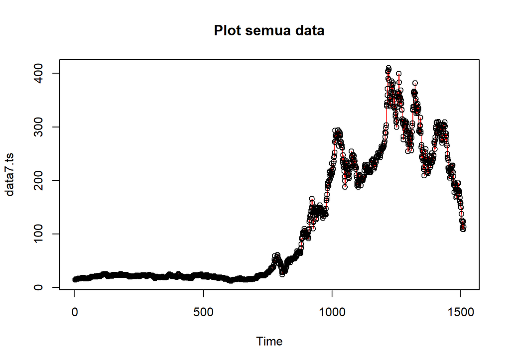

```r
#Membuat plot time series
plot(data7.ts, col="red",main="Plot semua data")
points(data7.ts)
```

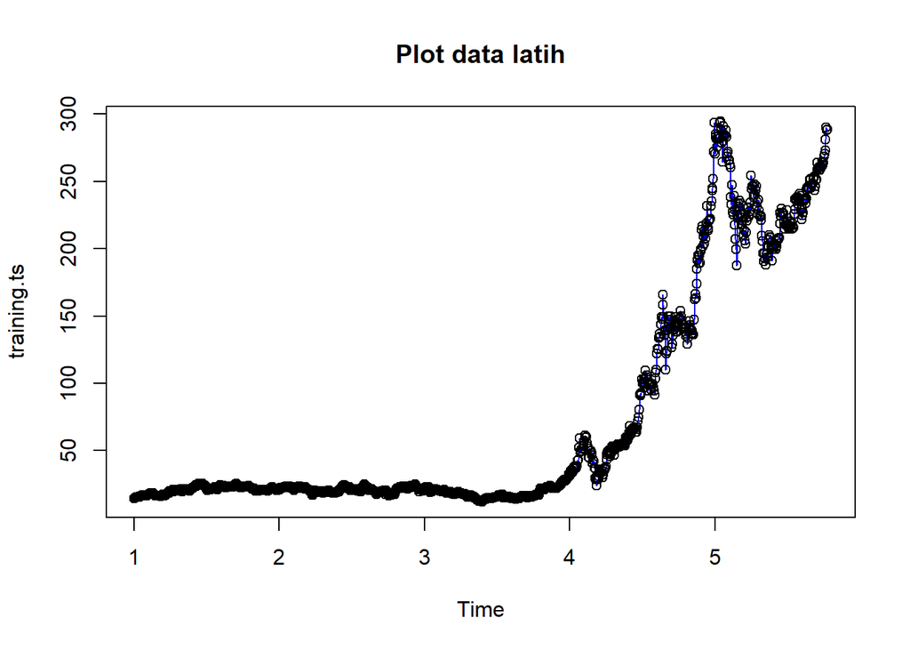

```r
plot(training.ts, col="blue",main="Plot data latih")
points(training.ts)
```

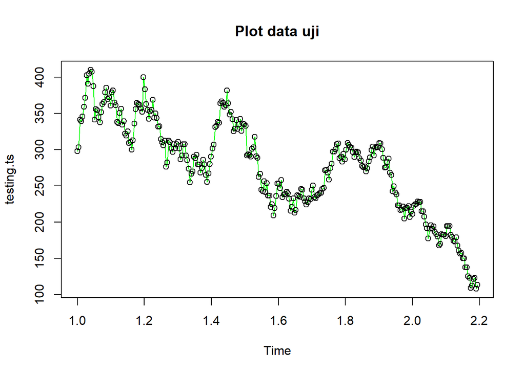

```r
plot(testing.ts, col="green",main="Plot data uji")
points(testing.ts)
```

### Winter Aditif

Perhitungan dengan model aditif dilakukan jika plot data asli menunjukkan fluktuasi musiman yang relatif stabil (konstan).

#### Pemulusan

```r
#Pemulusan dengan winter aditif
winter1 <- HoltWinters(training.ts,alpha=0.2,beta=0.1,gamma=0.1,seasonal = "additive")
winter1$fitted
```

```
## Time Series:
## Start = c(2, 1)
## End = c(5, 197)
## Frequency = 253
##               xhat     level         trend       season
## 2.000000  21.01868  21.99813 -0.0033708300 -0.976080505
## 2.003953  21.13374  21.98595 -0.0042510105 -0.847965225
## 2.007905  22.44280  21.97602 -0.0048191204  0.471598356
## 2.011858  22.25248  21.96811 -0.0051284775  0.289497558
## 2.015810  22.32269  21.96169 -0.0052580577  0.366266993
## 2.019763  22.52965  21.95589 -0.0053119493  0.579074321
## 2.023715  22.41259  21.95065 -0.0053049503  0.467247574
## 2.027668  22.66508  21.94576 -0.0052633970  0.724589807
## 2.031621  23.13325  21.94161 -0.0051517112  1.196793009
## 2.035573  22.95991  21.93861 -0.0049367723  1.026237684
## 2.039526  23.32390  21.93596 -0.0047082993  1.392649420
## 2.043478  23.43126  21.93340 -0.0044929096  1.502355265
## 2.047431  23.51827  21.93012 -0.0043715566  1.592517001
## 2.051383  23.06303  21.92596 -0.0043502577  1.141419190
## 2.055336  22.51655  21.92087 -0.0044242372  0.600100665
## 2.059289  22.87017  21.91501 -0.0045685856  0.959732420
## 2.063241  23.31963  21.90774 -0.0048386477  1.416736036
## 2.067194  23.07331  21.89937 -0.0051913368  1.179134261
## 2.071146  23.63598  21.89045 -0.0055642858  1.751097372
## 2.075099  23.28182  21.88182 -0.0058706215  1.405866135
## 2.079051  22.90375  21.87626 -0.0058403329  1.033330258
## 2.083004  22.19409  21.87300 -0.0055818778  0.326674131
## 2.086957  22.24175  21.87033 -0.0052903536  0.376703119
## 2.090909  22.97283  21.86963 -0.0048319070  1.108037752
## 2.094862  20.99268  21.87023 -0.0042885642 -0.873264300
## 2.098814  20.67483  21.87047 -0.0038354176 -1.191810727
## 2.102767  21.02909  21.87060 -0.0034385635 -0.838076873
## 2.106719  21.56132  21.87108 -0.0030469860 -0.306716225
## 2.110672  21.47841  21.87124 -0.0027266973 -0.390099624
## 2.114625  22.26873  21.87030 -0.0025482643  0.400984380
## 2.118577  22.37655  21.86827 -0.0024962128  0.510777178
## 2.122530  22.33519  21.86366 -0.0027072032  0.474236348
## 2.126482  22.23743  21.85752 -0.0030509949  0.382969530
## 2.130435  23.09282  21.85098 -0.0033997120  1.245243574
## 2.134387  23.48376  21.84461 -0.0036961724  1.642843044
```

[output cut: 906 more lines]

```
## 5.719368 259.13914 256.75964  0.8579653422  1.521528522
## 5.723320 259.75883 257.48845  0.8450495465  1.425326441
## 5.727273 260.69222 258.06307  0.8180065607  1.811143704
## 5.731225 259.92015 258.84463  0.8143623555  0.261152359
## 5.735178 261.17025 259.71430  0.8198924712  0.636060140
## 5.739130 261.55981 260.48347  0.8148205787  0.261513616
## 5.743083 263.35854 261.89367  0.8743581035  0.590511910
## 5.747036 264.14624 262.46232  0.8437870955  0.840137545
## 5.750988 265.43107 263.27286  0.8404625145  1.317750729
## 5.754941 267.11522 264.74177  0.9033077957  1.470136999
## 5.758893 268.93201 266.29403  0.9682031593  1.669773756
## 5.762846 270.34276 268.03050  1.0450298719  1.267226822
## 5.766798 273.84344 271.20898  1.2583748632  1.376080038
## 5.770751 278.34727 275.70601  1.5822397347  1.059027324
## 5.774704 281.90600 279.23679  1.7770941715  0.892114674
```

```r
xhat1 <- winter1$fitted[,2]

winter1.opt<- HoltWinters(training.ts, alpha= NULL,  beta = NULL, gamma = NULL, seasonal = "additive")
winter1.opt
```

```
## Holt-Winters exponential smoothing with trend and additive seasonal component.
##
## Call:
## HoltWinters(x = training.ts, alpha = NULL, beta = NULL, gamma = NULL,     seasonal = "additive")
##
## Smoothing parameters:
##  alpha: 0.9326844
##  beta : 0.003416642
##  gamma: 0.1140098
##
## Coefficients:
##               [,1]
## a    287.265776653
## b      0.456573859
## s1     1.346516695
## s2     1.039676694
## s3     1.376629297
## s4     1.621155175
## s5     1.158235056
## s6     0.738907141
## s7     0.117796684
## s8     0.198052871
## s9    -0.613387414
## s10   -0.523929205
## s11   -0.838295523
## s12   -0.948164825
## s13   -0.149887676
## s14   -0.869274427
## s15   -2.315210031
## s16   -1.908182604
## s17   -2.064644205
## s18   -1.882657968
## s19   -1.983340675
## s20   -2.067008678
## s21   -1.958443800
## s22   -1.109912126
## s23   -1.595866654
## s24   -1.496964586
## s25   -1.304033884
## s26   -1.131527616
```

[output cut: 212 more lines]

```
## s239   1.058553473
## s240   0.672907140
## s241   0.719505121
## s242   0.273686739
## s243   0.329687747
## s244   0.379780840
## s245   0.419669993
## s246   0.852049305
## s247   1.345095094
## s248   1.364424005
## s249   1.471756741
## s250   0.639341320
## s251   1.373925432
## s252   1.259020121
## s253   1.342531946
```

```r
winter1.opt$fitted
```

```
## Time Series:
## Start = c(2, 1)
## End = c(5, 197)
## Frequency = 253
##               xhat     level         trend      season
## 2.000000  21.01868  21.99813 -0.0033708300 -0.97608051
## 2.003953  21.10223  21.95371 -0.0035110713 -0.84796522
## 2.007905  22.42119  21.95309 -0.0035011949  0.47159836
## 2.011858  22.24134  21.95532 -0.0034816058  0.28949756
## 2.015810  22.31899  21.95619 -0.0034667490  0.36626699
## 2.019763  22.52928  21.95366 -0.0034635268  0.57907432
## 2.023715  22.41466  21.95088 -0.0034612156  0.46724757
## 2.027668  22.66855  21.94742 -0.0034612068  0.72458981
## 2.031621  23.13927  21.94594 -0.0034544505  1.19679301
## 2.035573  22.96969  21.94689 -0.0034393937  1.02623768
## 2.039526  23.33420  21.94498 -0.0034341460  1.39264942
## 2.043478  23.44091  21.94199 -0.0034326570  1.50235527
## 2.047431  23.52429  21.93522 -0.0034440548  1.59251700
## 2.051383  23.06511  21.92715 -0.0034598525  1.14141919
## 2.055336  22.51493  21.91830 -0.0034782555  0.60010066
## 2.059289  22.86585  21.90961 -0.0034960783  0.95973242
## 2.063241  23.31076  21.89755 -0.0035253260  1.41673604
## 2.067194  23.06143  21.88585 -0.0035532510  1.17913426
## 2.071146  23.62351  21.87599 -0.0035748178  1.75109737
## 2.075099  23.27204  21.86976 -0.0035838802  1.40586614
## 2.079051  22.90649  21.87671 -0.0035479040  1.03333026
## 2.083004  22.20581  21.88265 -0.0035154679  0.32667413
## 2.086957  22.25500  21.88180 -0.0035063643  0.37670312
## 2.090909  22.99188  21.88731 -0.0034755504  1.10803775
## 2.094862  21.01470  21.89142 -0.0034496626 -0.87326430
## 2.098814  20.69330  21.88855 -0.0034476500 -1.19181073
## 2.102767  21.04487  21.88639 -0.0034432792 -0.83807687
## 2.106719  21.57634  21.88649 -0.0034311643 -0.30671622
## 2.110672  21.49045  21.88398 -0.0034280050 -0.39009962
## 2.114625  22.27519  21.87764 -0.0034379532  0.40098438
## 2.118577  22.37794  21.87061 -0.0034502384  0.51077718
## 2.122530  22.32677  21.85603 -0.0034882777  0.47423635
## 2.126482  22.22381  21.84436 -0.0035162324  0.38296953
## 2.130435  23.07900  21.83729 -0.0035283718  1.24524357
## 2.134387  23.47213  21.83282 -0.0035315652  1.64284304
```

[output cut: 906 more lines]

```
## 5.719368 259.66722 258.22190  0.3777606508  1.06756256
## 5.723320 258.55285 257.50480  0.3740199159  0.67402899
## 5.727273 258.82260 257.74249  0.3735541023  0.70655483
## 5.731225 260.34361 259.68987  0.3789312955  0.27481458
## 5.735178 260.63774 259.93173  0.3784629958  0.32754719
## 5.739130 261.30466 260.57033  0.3793517933  0.35497624
## 5.743083 264.79623 263.96414  0.3896511077  0.44243482
## 5.747036 262.81050 261.58723  0.3801987443  0.84307372
## 5.750988 264.75795 263.05821  0.3839255691  1.31581339
## 5.754941 268.74883 267.00069  0.3960838592  1.35205896
## 5.758893 270.75697 268.89947  0.4012180494  1.45628178
## 5.762846 272.16040 271.18133  0.4076435323  0.57142371
## 5.766798 281.58780 279.84287  0.4358441399  1.30908326
## 5.770751 289.89449 288.15886  0.4627677719  1.27286899
## 5.774704 288.73922 286.93860  0.4570174713  1.34360033
```

```r
xhat1.opt <- winter1.opt$fitted[,2]
```

#### Peramalan

```r
#Forecast
forecast1 <- predict(winter1, n.ahead = 303)
forecast1.opt <- predict(winter1.opt, n.ahead = 303)
```

#### Plot Deret Waktu

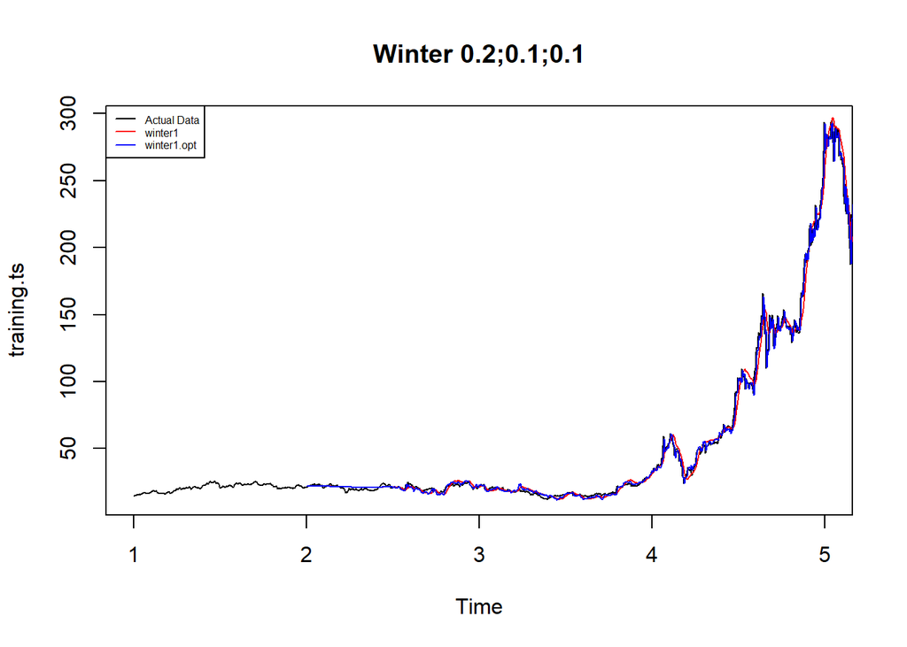

```r
#Plot time series
plot(training.ts,main="Winter 0.2;0.1;0.1",type="l",col="black",
     xlim=c(1,5),pch=12)
lines(xhat1,type="l",col="red")
lines(xhat1.opt,type="l",col="blue")
lines(forecast1,type="l",col="red")
lines(forecast1.opt,type="l",col="blue")
legend("topleft",c("Actual Data",expression(paste(winter1)),
                   expression(paste(winter1.opt))),cex=0.5,
       col=c("black","red","blue"),lty=1)
```

#### Akurasi Data Latih

```r
#Akurasi data training
SSE1<-winter1$SSE
MSE1<-winter1$SSE/length(training.ts)
RMSE1<-sqrt(MSE1)
akurasi1 <- matrix(c(SSE1,MSE1,RMSE1))
row.names(akurasi1)<- c("SSE", "MSE", "RMSE")
colnames(akurasi1) <- c("Akurasi")
akurasi1
```

```
##           Akurasi
## SSE  47046.081561
## MSE     38.913219
## RMSE     6.238046
```

```r
SSE1.opt<-winter1.opt$SSE
MSE1.opt<-winter1.opt$SSE/length(training.ts)
RMSE1.opt<-sqrt(MSE1.opt)
akurasi1.opt <- matrix(c(SSE1.opt,MSE1.opt,RMSE1.opt))
row.names(akurasi1.opt)<- c("SSE1.opt", "MSE1.opt", "RMSE1.opt")
colnames(akurasi1.opt) <- c("Akurasi")
akurasi1.opt
```

```
##               Akurasi
## SSE1.opt  18552.10743
## MSE1.opt     15.34500
## RMSE1.opt     3.91727
```

```r
akurasi1.train = data.frame(Model_Winter = c("Winter 1","Winter1 optimal"),
                            Nilai_SSE=c(SSE1,SSE1.opt),
                            Nilai_MSE=c(MSE1,MSE1.opt),Nilai_RMSE=c(RMSE1,RMSE1.opt))
akurasi1.train
```

```
##      Model_Winter Nilai_SSE Nilai_MSE Nilai_RMSE
## 1        Winter 1  47046.08  38.91322   6.238046
## 2 Winter1 optimal  18552.11  15.34500   3.917270
```

#### Akurasi Data Uji

```r
#Akurasi Data Testing
forecast1<-data.frame(forecast1)
testing.ts<-data.frame(testing.ts)
selisih1<-forecast1-testing.ts
SSEtesting1<-sum(selisih1^2)
MSEtesting1<-SSEtesting1/length(testing.ts)

forecast1.opt<-data.frame(forecast1.opt)
selisih1.opt<-forecast1.opt-testing.ts
SSEtesting1.opt<-sum(selisih1.opt^2)
MSEtesting1.opt<-SSEtesting1.opt/length(testing.ts)
```

### Winter Multiplikatif

Model multiplikatif digunakan cocok digunakan jika plot data asli menunjukkan fluktuasi musiman yang bervariasi.

#### Pemulusan

```r
#Pemulusan dengan winter multiplikatif
winter2 <- HoltWinters(training.ts,alpha=0.2,beta=0.1,gamma=0.3,seasonal = "multiplicative")
winter2$fitted
```

```
## Time Series:
## Start = c(2, 1)
## End = c(5, 197)
## Frequency = 253
##               xhat     level         trend    season
## 2.000000  21.02446  21.99813 -0.0033708300 0.9558850
## 2.003953  21.13869  21.98434 -0.0044125916 0.9617271
## 2.007905  22.44796  21.97299 -0.0051063050 1.0218536
## 2.011858  22.25600  21.96385 -0.0055099905 1.0135558
## 2.015810  22.32506  21.95636 -0.0057072740 1.0170567
## 2.019763  22.53103  21.94966 -0.0058068106 1.0267582
## 2.023715  22.41315  21.94365 -0.0058269030 1.0216668
## 2.027668  22.66485  21.93812 -0.0057971748 1.0333991
## 2.031621  23.13205  21.93345 -0.0056844995 1.0549203
## 2.035573  22.95836  21.93003 -0.0054579232 1.0471517
## 2.039526  23.32188  21.92705 -0.0052100729 1.0638648
## 2.043478  23.42933  21.92425 -0.0049696644 1.0688915
## 2.047431  23.51657  21.92078 -0.0048199475 1.0730340
## 2.051383  23.06159  21.91647 -0.0047683646 1.0524782
## 2.055336  22.51515  21.91127 -0.0048112546 1.0277857
## 2.059289  22.86920  21.90533 -0.0049244538 1.0442364
## 2.063241  23.31926  21.89801 -0.0051645511 1.0651548
## 2.067194  23.07290  21.88960 -0.0054887166 1.0543219
## 2.071146  23.63581  21.88065 -0.0058345387 1.0805030
## 2.075099  23.28028  21.87202 -0.0061147724 1.0646841
## 2.079051  22.90172  21.86648 -0.0060573887 1.0476339
## 2.083004  22.19259  21.86327 -0.0057719273 1.0153306
## 2.086957  22.24010  21.86067 -0.0054552235 1.0176107
## 2.090909  22.97024  21.86004 -0.0049723298 1.0510256
## 2.094862  20.99260  21.86073 -0.0044059473 0.9604816
## 2.098814  20.67506  21.86106 -0.0039325883 0.9459184
## 2.102767  21.02907  21.86127 -0.0035179778 0.9620873
## 2.106719  21.56087  21.86183 -0.0031105620 0.9863740
## 2.110672  21.47804  21.86206 -0.0027767853 0.9825594
## 2.114625  22.26827  21.86117 -0.0025876750 1.0187425
## 2.118577  22.37656  21.85919 -0.0025274867 1.0237871
## 2.122530  22.33545  21.85459 -0.0027338911 1.0221306
## 2.126482  22.23769  21.84845 -0.0030754105 1.0179589
## 2.130435  23.09364  21.84189 -0.0034229562 1.0574750
## 2.134387  23.48480  21.83551 -0.0037187346 1.0757155
```

[output cut: 906 more lines]

```
## 5.719368 259.02569 235.80239  0.2757619222 1.0972031
## 5.723320 258.09415 235.98111  0.2660583387 1.0924751
## 5.727273 259.58847 236.30439  0.2717798157 1.0972723
## 5.731225 245.69625 236.74414  0.2885767534 1.0365500
## 5.735178 252.60532 239.83053  0.5683588995 1.0507757
## 5.739130 250.61723 241.98084  0.7265532254 1.0325900
## 5.743083 255.76198 245.40342  0.9961559090 1.0379969
## 5.747036 257.89012 247.56875  1.1130734737 1.0370284
## 5.750988 261.44507 249.85631  1.2305222853 1.0412536
## 5.754941 263.75140 252.45600  1.3674393072 1.0391136
## 5.758893 269.74334 255.09541  1.4946358671 1.0512619
## 5.762846 270.04618 257.16649  1.5522810361 1.0437827
## 5.766798 274.34206 260.81956  1.7623597350 1.0447865
## 5.770751 279.11861 265.58629  2.0627967127 1.0428528
## 5.774704 282.99086 269.36963  2.2348513185 1.0419226
```

```r
xhat2 <- winter2$fitted[,2]

winter2.opt<- HoltWinters(training.ts, alpha= NULL,  beta = NULL, gamma = NULL, seasonal = "multiplicative")
winter2.opt$fitted
```

```
## Time Series:
## Start = c(2, 1)
## End = c(5, 197)
## Frequency = 253
##               xhat     level         trend    season
## 2.000000  21.02446  21.99813 -3.370830e-03 0.9558850
## 2.003953  21.10394  21.94722 -3.428145e-03 0.9617271
## 2.007905  22.42119  21.94511 -3.426556e-03 1.0218536
## 2.011858  22.24122  21.94717 -3.419942e-03 1.0135558
## 2.015810  22.31895  21.94806 -3.414749e-03 1.0170567
## 2.019763  22.52931  21.94559 -3.413611e-03 1.0267582
## 2.023715  22.41473  21.94279 -3.412869e-03 1.0216668
## 2.027668  22.66854  21.93932 -3.412940e-03 1.0333991
## 2.031621  23.13901  21.93778 -3.410679e-03 1.0549203
## 2.035573  22.96956  21.93868 -3.405477e-03 1.0471517
## 2.039526  23.33419  21.93682 -3.403617e-03 1.0638648
## 2.043478  23.44124  21.93383 -3.403124e-03 1.0688915
## 2.047431  23.52485  21.92708 -3.407149e-03 1.0730340
## 2.051383  23.06566  21.91899 -3.412808e-03 1.0524782
## 2.055336  22.51536  21.91009 -3.419424e-03 1.0277857
## 2.059289  22.86657  21.90132 -3.425875e-03 1.0442364
## 2.063241  23.31176  21.88923 -3.436315e-03 1.0651548
## 2.067194  23.06222  21.87743 -3.446397e-03 1.0543219
## 2.071146  23.62411  21.86745 -3.454284e-03 1.0805030
## 2.075099  23.27147  21.86109 -3.457790e-03 1.0646841
## 2.079051  22.90583  21.86780 -3.445529e-03 1.0476339
## 2.083004  22.20564  21.87379 -3.434151e-03 1.0153306
## 2.086957  22.25478  21.87307 -3.430868e-03 1.0176107
## 2.090909  22.99128  21.87851 -3.420180e-03 1.0510256
## 2.094862  21.01462  21.88266 -3.411047e-03 0.9604816
## 2.098814  20.69340  21.87993 -3.410228e-03 0.9459184
## 2.102767  21.04502  21.87774 -3.408755e-03 0.9620873
## 2.106719  21.57633  21.87779 -3.404580e-03 0.9863740
## 2.110672  21.49046  21.87532 -3.403460e-03 0.9825594
## 2.114625  22.27542  21.86901 -3.406959e-03 1.0187425
## 2.118577  22.37848  21.86194 -3.411375e-03 1.0237871
## 2.122530  22.32740  21.84740 -3.424794e-03 1.0221306
## 2.126482  22.22424  21.83559 -3.434912e-03 1.0179589
## 2.130435  23.07930  21.82836 -3.439491e-03 1.0574750
## 2.134387  23.47249  21.82379 -3.440850e-03 1.0757155
```

[output cut: 906 more lines]

```
## 5.719368 248.84413 234.65030  1.849660e-01 1.0596540
## 5.723320 252.77169 243.14474  1.949857e-01 1.0387605
## 5.727273 257.34901 248.28993  2.009548e-01 1.0356477
## 5.731225 251.85766 251.27610  2.043133e-01 1.0015001
## 5.735178 264.64121 259.07857  2.134753e-01 1.0206299
## 5.739130 259.59183 255.96199  2.094598e-01 1.0133519
## 5.743083 266.29176 260.62431  2.148292e-01 1.0209042
## 5.747036 265.09167 256.85102  2.100202e-01 1.0312402
## 5.750988 269.06365 256.07735  2.088341e-01 1.0498562
## 5.754941 270.39561 255.86001  2.083202e-01 1.0559510
## 5.758893 273.69266 256.03754  2.082831e-01 1.0680863
## 5.762846 265.26911 255.46041  2.073360e-01 1.0375541
## 5.766798 283.27214 269.51183  2.240295e-01 1.0501835
## 5.770751 291.75655 275.61372  2.311171e-01 1.0576836
## 5.774704 289.31287 272.68148  2.273026e-01 1.0601083
```

```r
xhat2.opt <- winter2.opt$fitted[,2]
```

#### Peramalan

```r
#Forecast
forecast2 <- predict(winter2, n.ahead = 303)
forecast2.opt <- predict(winter2.opt, n.ahead = 303)
```

#### Plot Deret Waktu

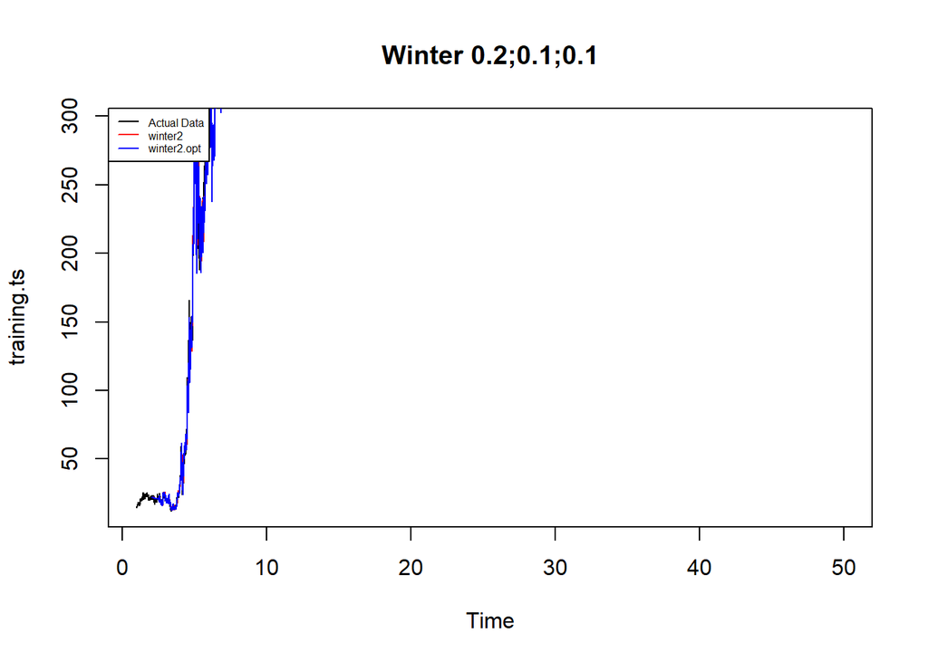

```r
#Plot time series
plot(training.ts,main="Winter 0.2;0.1;0.1",type="l",col="black",
     xlim=c(1,50),pch=12)
lines(xhat2,type="l",col="red")
lines(xhat2.opt,type="l",col="blue")
lines(forecast2,type="l",col="red")
lines(forecast2.opt,type="l",col="blue")
legend("topleft",c("Actual Data",expression(paste(winter2)),
                   expression(paste(winter2.opt))),cex=0.5,
       col=c("black","red","blue"),lty=1)
```

#### Akurasi Data Latih

```r
#Akurasi data training
SSE2<-winter2$SSE
MSE2<-winter2$SSE/length(training.ts)
RMSE2<-sqrt(MSE2)
akurasi1 <- matrix(c(SSE2,MSE2,RMSE2))
row.names(akurasi1)<- c("SSE2", "MSE2", "RMSE2")
colnames(akurasi1) <- c("Akurasi lamda=0.2")
akurasi1
```

```
##       Akurasi lamda=0.2
## SSE2       70068.665341
## MSE2          57.955885
## RMSE2          7.612876
```

```r
SSE2.opt<-winter2.opt$SSE
MSE2.opt<-winter2.opt$SSE/length(training.ts)
RMSE2.opt<-sqrt(MSE2.opt)
akurasi1.opt <- matrix(c(SSE2.opt,MSE2.opt,RMSE2.opt))
row.names(akurasi1.opt)<- c("SSE2.opt", "MSE2.opt", "RMSE2.opt")
colnames(akurasi1.opt) <- c("Akurasi")
akurasi1.opt
```

```
##                Akurasi
## SSE2.opt  24590.297158
## MSE2.opt     20.339369
## RMSE2.opt     4.509919
```

```r
akurasi2.train = data.frame(Model_Winter = c("Winter 1","winter2 optimal"),
                            Nilai_SSE=c(SSE2,SSE2.opt),
                            Nilai_MSE=c(MSE2,MSE2.opt),Nilai_RMSE=c(RMSE2,RMSE2.opt))
akurasi2.train
```

```
##      Model_Winter Nilai_SSE Nilai_MSE Nilai_RMSE
## 1        Winter 1  70068.67  57.95589   7.612876
## 2 winter2 optimal  24590.30  20.33937   4.509919
```

#### Akurasi Data Uji

```r
#Akurasi Data Testing
forecast2<-data.frame(forecast2)
testing.ts<-data.frame(testing.ts)
selisih2<-forecast2-testing.ts
SSEtesting2<-sum(selisih2^2)
MSEtesting2<-SSEtesting2/length(testing.ts)

forecast2.opt<-data.frame(forecast2.opt)
selisih2.opt<-forecast2.opt-testing.ts
SSEtesting2.opt<-sum(selisih2.opt^2)
MSEtesting2.opt<-SSEtesting2.opt/length(testing.ts)
```